# fastQR: factorization, updating and statistical applications

Mauro Bernardi, Claudio Busatto and Manuela Cattelan

16 November 2026

A QR factorization provides a numerical representation that can be reused across estimation, prediction and changes to the data. This guide develops that idea from the construction of the factors to sliding-window regression and ridge model selection. The mathematical discussion explains what each representation retains, while the R examples examine both its numerical accuracy and the work required to compute or update it.

# 1 From a matrix to a verified QR factorization

A design matrix often appears in several related calculations: estimating coefficients, producing predictions, adding observations or changing the set of predictors. A QR factorization records its geometry in a form that can support each of these operations. Understanding what the factors contain is therefore useful before deciding whether to store an explicit orthogonal basis, retain only a triangular factor or keep the orthogonal transformations in compact form.

This chapter introduces those representations through the identities they satisfy. The examples check reconstruction and orthogonality separately, then examine the column-ordering convention used by pivoted QR. These checks provide a common basis for the update and regression examples that follow.

The examples use **fastQR 1.1.6**, `ggplot2` for figures and `knitr` for tables. All code uses explicit `fastQR::` or `base::` namespaces because both packages export a function named `qr`. For the examples in this guide, use the accompanying verified source build described on the Overview page. No attachment with `library(fastQR)` is required below.

## 1.1 Full, thin and compact representations

Let $X\in\mathbb R^{n\times p}$ have full column rank, with $n>p$. Its thin factorization is
$$X=Q_1R_1,\qquad Q_1^\top Q_1=I_p,$$
where $Q_1$ is $n\times p$ and $R_1$ is nonsingular, upper triangular and $p\times p$. The columns of $Q_1$ are orthonormal; $Q_1Q_1^\top$ is a projector and need not equal $I_n$.

The full factorization completes $Q_1$ to an orthogonal matrix by adding $n-p$ orthonormal columns:
$$\begin{aligned}
Q&=[Q_1,Q_2]\in\mathbb R^{n\times n},
& Q_2&\in\mathbb R^{n\times(n-p)},\\
R&=\begin{pmatrix}R_1\\0_{(n-p)\times p}\end{pmatrix}\in\mathbb
R^{n\times p},
& X&=QR=Q_1R_1.
\end{aligned}$$
Here $Q_1^\top Q_2=0_{p\times(n-p)}$ and $Q_2^\top Q_2=I_{n-p}$, so $Q_2$ spans the orthogonal complement of the column space of $X$. The zero block in $R$ contributes nothing to the product; the thin representation therefore suffices to reconstruct $X$.

The orthogonal complement is needed for some operations on complete factors, but it contributes nothing to the reconstruction of the original design. Its storage can be substantial when $n$ is much larger than $p$, which motivates retaining the thin factors whenever the subsequent calculation permits it. A compact representation goes a step further by storing the Householder transformations that define Q and forming its columns only when requested.

The triangular factor $R_1$ should also be distinguished from the symmetric cross-product matrix. An upper triangular matrix is not generally symmetric or positive definite; under full column rank, the positive-definite matrix is $R_1^\top R_1=X^\top X$.

| Task | Function | Representation |
| --- | --- | --- |
| Work directly with $Q$ and $R$ | `fastQR::qr()` | Explicit factors; full or thin |
| Store Householder information compactly | `fastQR::qr_fast()` | Packed factorization, optionally pivoted |
| Extract factors from packed output | `qr_Q()`, `qr_R()` | Form only the factors needed |
| Retain a triangular factor only | `qrchol()`, `rchol()` | $R$ satisfying $R^\top R=X^\top X$ |

### 1.1.1 Rank and rectangular shapes

The factorization identity itself does not require a unique least-squares coefficient vector. If a design has dependent columns, a triangular factor can still represent it, but solving an unpivoted triangular system with a zero diagonal is no longer the full-column-rank calculation derived above. A rank-revealing pivoted factorization separates that situation from an ordinary full-rank solve.

A wide design with $p>n$ also admits an orthogonal factorization, with Q of size $n\times n$ and R of size $n\times p$. It cannot have full column rank, so its unpenalized coefficient vector is not uniquely determined by the fitted response. The `qr()` and compact `qr_fast()` interfaces support that representation; the thin-factor interface has a different input contract. Ordinary least-squares interfaces retain their full-column-rank restrictions. Positive-penalty ridge fits also support wide designs; the chapter on ridge with growing designs develops this case through augmented least squares.

The declared numerical rank and the number of stored Householder transformations also serve different purposes. Extraction through `qr_Q()` and `qr_R()` follows their documented rank-dependent output rule. `qr_Q_full()` constructs the complete orthogonal transformation from the compact information when that full transformation is required.

## 1.2 A first reproducible example

We generate a modest, full-rank design so that the dimensions and checks are easy to inspect. `complete = FALSE` avoids constructing an unnecessary $n\times n$ matrix.

```r
set.seed(2026)
n <- 120L
p <- 6L
X <- matrix(rnorm(n * p), n, p)
thin <- fastQR::qr(X, type = "householder", complete = FALSE)
full <- fastQR::qr(X, type = "householder", complete = TRUE)
knitr::kable(data.frame(
  representation = c("Thin", "Full"),
  Q_rows = c(nrow(thin$Q), nrow(full$Q)),
  Q_columns = c(ncol(thin$Q), ncol(full$Q)),
  R_rows = c(nrow(thin$R), nrow(full$R)),
  R_columns = c(ncol(thin$R), ncol(full$R))))
```

| representation | Q_rows | Q_columns | R_rows | R_columns |
| --- | --- | --- | --- | --- |
| Thin | 120 | 6 | 6 | 6 |
| Full | 120 | 120 | 120 | 6 |

The factorization has two distinct defining properties: multiplication of the factors reconstructs X, and the columns of Q have the required inner products. The checks below examine both properties. The full Q is compared with $I_n$ through $Q^\top Q$, whereas the thin Q is compared with $I_p$ through $Q_1^\top Q_1$. These different identity sizes are a direct consequence of the dimensions of the two representations.

The helper scales a matrix difference by the Frobenius norm of its reference. This makes discrepancies comparable across matrices with different overall magnitudes. Its denominator is bounded below by machine epsilon to avoid division by zero; for the nonzero reference matrices in this example it is the usual relative error. The same helper is reused when the design is updated.

```r
relative_error <- function(actual, reference) {
  norm(as.matrix(actual - reference), "F") /
    max(norm(as.matrix(reference), "F"), .Machine$double.eps)
}
checks <- c(
  thin_reconstruction = relative_error(thin$Q %*% thin$R, X),
  full_reconstruction = relative_error(full$Q %*% full$R, X),
  thin_orthogonality = relative_error(crossprod(thin$Q), diag(p)),
  full_orthogonality = relative_error(crossprod(full$Q), diag(n)),
  Gram_identity = relative_error(crossprod(thin$R), crossprod(X)))
knitr::kable(data.frame(check = names(checks), relative_error = unname(checks)),
             digits = 16)
```

| check | relative_error |
| --- | --- |
| thin_reconstruction | 2e-16 |
| full_reconstruction | 4e-16 |
| thin_orthogonality | 1e-16 |
| full_orthogonality | 4e-16 |
| Gram_identity | 2e-16 |

```r
stopifnot(max(checks) < 1e-10)
```

These are checks of the defining identities. Comparing two implementations’ entries of $Q$ and $R$ directly would be misleading: paired column/row sign changes can produce equally valid factors.

### 1.2.1 Recovering a least-squares coefficient vector

Once the thin factors are available, the response enters through its projection onto the columns of Q. For a response $y\in\mathbb R^n$, define $c=Q_1^\top y$. The least-squares coefficient vector satisfies $R_1\widehat\beta=c$, so a complete calculation needs a matrix-vector product followed by a triangular solve. Writing $R_1^{-1}c$ is a mathematical identity, but an implementation can obtain the result without constructing an inverse.

The following response combines a linear signal with a deterministic perturbation. The perturbation makes the residual nonzero, allowing us to check its orthogonality to the fitted column space as well as the coefficient calculation. It is a numerical example, rather than a simulation of a particular observation-noise model.

```r
demo_y <- drop(X %*% seq_len(p)) + sin(seq_len(n))
demo_projection <- crossprod(thin$Q, demo_y)
demo_coefficients <- backsolve(thin$R, demo_projection)
demo_fitted <- drop(X %*% demo_coefficients)
demo_residuals <- demo_y - demo_fitted
qr_derivation_checks <- c(
  coefficient_agreement = max(abs(demo_coefficients - lm.fit(X, demo_y)$coefficients)),
  fitted_projection = relative_error(demo_fitted, thin$Q %*% demo_projection),
  residual_orthogonality = max(abs(crossprod(thin$Q, demo_residuals))) /
    max(1, sqrt(sum(demo_y^2))))
stopifnot(max(qr_derivation_checks) < 1e-10)
knitr::kable(data.frame(check = names(qr_derivation_checks),
                        error = unname(qr_derivation_checks)), digits = 12)
```

| check | error |
| --- | --- |
| coefficient_agreement | 0 |
| fitted_projection | 0 |
| residual_orthogonality | 0 |

The response projection has p entries, whereas the fitted response and residual have n. Multiplication by the thin Q maps between those coordinate systems. The near-zero value of $Q_1^\top e$ verifies the defining least-squares geometry, while comparison with `lm.fit()` checks the resulting coefficients against a separate implementation.

## 1.3 Pivoting: keep track of the column order

Column pivoting changes the order in which the columns are factorized. With the permutation matrix returned by `qr_pivot2perm()`, the convention used here is
$$X=QRP,\qquad XP^\top=QR.$$
Thus the correct Gram check is $R^\top R=PX^\top XP^\top$, not generally $R^\top R=X^\top X$.

Pivoting also changes the coordinates of the coefficient vector. If $z=P\beta$, then $X\beta=QRz$. The triangular solve therefore returns $\widehat z$ in pivoted order; the original predictor order is recovered by $\widehat\beta=P^\top\widehat z$. Restoring that order is necessary before interpreting individual coefficients or multiplying them by an unpermuted prediction design.

```r
packed <- fastQR::qr_fast(X, pivot = TRUE)
Q <- fastQR::qr_Q(packed$qr, tau = packed$qraux,
                  rank = packed$rank, complete = FALSE)
R <- fastQR::qr_R(packed$qr, rank = NULL, complete = FALSE)
P <- fastQR::qr_pivot2perm(packed$pivot)
pivot_checks <- c(
  reconstruction = relative_error(Q %*% R %*% P, X),
  permuted_Gram = relative_error(crossprod(R), crossprod(X %*% t(P))))
knitr::kable(data.frame(check = names(pivot_checks), error = pivot_checks),
             digits = 16, row.names = FALSE)
```

| check | error |
| --- | --- |
| reconstruction | 2e-16 |
| permuted_Gram | 1e-16 |

```r
stopifnot(max(pivot_checks) < 1e-10)
pivoted_coefficients <- backsolve(R, crossprod(Q, demo_y))
original_order_coefficients <- drop(t(P) %*% pivoted_coefficients)
pivot_derivation_error <- max(abs(original_order_coefficients - demo_coefficients))
stopifnot(pivot_derivation_error < 1e-10)
```

All subsequent update examples start from **unpivoted** factors, so that insertion and deletion positions refer directly to the original columns. Rank-deficient designs require additional care; the worked examples retain full column rank.

## 1.4 Triangular factors and linear systems

A triangular factor can be useful even when the subsequent calculation does not require an explicit orthogonal basis. The identity $R^\top R=X^\top X$ provides the cross-product information through R, with storage proportional to $p^2$. Two valid factors can have different row signs while satisfying the same identity, so agreement of the invariant is more informative here than equality of their entries.

The final part of the example solves a square system $Au=b$, where $A=X^\top X+I_p$. In this call, `qrsolve(A, b)` factorizes A and solves for u. It is distinct from directly computing least-squares coefficients by factorizing X and projecting a response. Adding the identity makes this demonstration system positive definite; its purpose is to show the solver interface on an easily checked calculation.

```r
R_qr <- fastQR::qrchol(X)
R_only <- fastQR::rchol(X)
stopifnot(relative_error(crossprod(R_qr), crossprod(X)) < 1e-10,
          relative_error(crossprod(R_only), crossprod(X)) < 1e-10)

A <- crossprod(X) + diag(p)
b <- seq_len(p)
solution <- fastQR::qrsolve(A, b, type = "QR")
relative_error(A %*% solution, b)
```

```
## [1] 6.092069e-16
```

```r
stopifnot(relative_error(A %*% solution, b) < 1e-10)
```

The square system above is deliberately well conditioned. Later examples distinguish factorization error from the sensitivity of a least-squares solution to an ill-conditioned design.

# 2 Updating a factorization as the data change

Many statistical calculations involve a sequence of designs that differ by only a few observations or predictors. A moving-window analysis, for example, repeatedly removes the oldest observation and includes a new one. Recomputing a factorization at every step repeats work on the part of the design that has not changed.

Updating and downdating use the existing factors to incorporate that local change. The choice of representation remains important: `qrupdate()` and `qrdowndate()` modify QR factors, whereas `rupdate()` and `rdowndate()` retain only the triangular information. The examples first examine individual insertions and deletions, where the resulting design is easy to reconstruct, before combining the operations in a repeated regression calculation.

## 2.1 Insert and remove observations

We use full factors as inputs to the QR update routines in these examples. A batch containing $m$ new rows is supplied as a **$p\times m$ matrix** `U`: its transpose is appended to the design. The position `k` is one-based; `k = n + 1` appends observations.

```r
set.seed(2027)
n <- 120L
p <- 6L
X <- matrix(rnorm(n * p), n, p)
initial <- fastQR::qr(X, complete = TRUE)
U <- matrix(rnorm(p * 3L), p, 3L)
X_added <- rbind(X, t(U))
added <- fastQR::qrupdate(
  Q = initial$Q, R = initial$R, k = n + 1L, U = U,
  type = "row", fast = FALSE, complete = TRUE)
removed <- fastQR::qrdowndate(
  Q = added$Q, R = added$R, k = n + 1L, m = ncol(U),
  type = "row", fast = FALSE, complete = TRUE)
relative_error <- function(a, b) {
  norm(as.matrix(a - b), "F") / max(norm(as.matrix(b), "F"), .Machine$double.eps)
}
row_checks <- c(
  after_insertion = relative_error(added$Q %*% added$R, X_added),
  after_deletion = relative_error(removed$Q %*% removed$R, X))
knitr::kable(data.frame(operation = names(row_checks), error = row_checks),
             digits = 16, row.names = FALSE)
```

| operation | error |
| --- | --- |
| after_insertion | 4e-16 |
| after_deletion | 5e-16 |

```r
stopifnot(max(row_checks) < 1e-10)
```

Removing the same observations restores the original design, although it need not reproduce the original factor entries: signs and orthogonal completions can differ while representing the same matrix. Reconstruction therefore provides the relevant check. A downdated QR representation can also exist after a loss of rank, but a unique ordinary least-squares coefficient vector then requires additional treatment. The remaining design should be checked before its triangular factor is used in an unpivoted regression solve.

## 2.2 Insert and remove predictors

Adding a predictor changes the column space that a regression model can use. If V contains new columns, their components along the existing basis are $Q_1^\top V$, while $(I_n-Q_1Q_1^\top)V$ contains directions not already represented by X. A column-update algorithm incorporates those components and restores a triangular factor for the enlarged design. If the residual directions are dependent, the enlarged matrix does not acquire one independent direction per new column.

The insertion position changes the order of the predictors, so reconstruction is checked against a design assembled in exactly that order. Column deletion reverses the structural change, but the returned factors need not have the same entries as the starting factors.

For columns, `U` has the same number of rows as the design. Here two new predictors are inserted before column 3 and then removed from those same positions.

```r
V <- matrix(rnorm(n * 2L), n, 2L)
k <- 3L
X_wider <- cbind(X[, 1:2, drop = FALSE], V, X[, 3:p, drop = FALSE])
wider <- fastQR::qrupdate(
  initial$Q, initial$R, k = k, U = V, type = "column",
  fast = FALSE, complete = TRUE)
narrower <- fastQR::qrdowndate(
  wider$Q, wider$R, k = k, m = ncol(V), type = "column",
  fast = FALSE, complete = TRUE)
stopifnot(relative_error(wider$Q %*% wider$R, X_wider) < 1e-10,
          relative_error(narrower$Q %*% narrower$R, X) < 1e-10)
```

## 2.3 Update only the triangular factor

For new rows, the Gram identity becomes
$$X_{\mathrm{new}}^\top X_{\mathrm{new}}=X^\top X+UU^\top
=R^\top R+UU^\top.$$
`rupdate()` returns a new triangular factor satisfying this identity, without returning $Q$. To delete those rows, `rdowndate()` takes their values in `U` rather than their positions.

For predictor insertion, the required cross-products have a different structure. Appending $V\in\mathbb R^{n\times m}$ gives
$$[X,V]^\top[X,V]
=\begin{pmatrix}R^\top R&X^\top V\\V^\top X&V^\top
V\end{pmatrix}.$$
The old factor determines the upper-left block, but it does not contain the cross-products between X and the new predictors. This is why the R-only column-update interface also receives the design values. For row deletion, the values of the observations being removed determine the subtraction $UU^\top$; their positions alone would not supply that information.

```r
R_initial <- initial$R[seq_len(p), , drop = FALSE]
R_added <- fastQR::rupdate(X, R_initial, U = U, type = "row", fast = FALSE)
R_removed <- fastQR::rdowndate(R_added, U = U, type = "row", fast = FALSE)

# R-only column updates append new columns to the right.
R_wider <- fastQR::rupdate(X, R_initial, U = V, type = "column", fast = FALSE)
R_narrower <- fastQR::rdowndate(R_wider, k = p + 1L, m = ncol(V),
                               type = "column", fast = FALSE)
r_checks <- c(
  add_rows = relative_error(crossprod(R_added), crossprod(X_added)),
  remove_rows = relative_error(crossprod(R_removed), crossprod(X)),
  add_columns = relative_error(crossprod(R_wider), crossprod(cbind(X, V))),
  remove_columns = relative_error(crossprod(R_narrower), crossprod(X)))
knitr::kable(data.frame(operation = names(r_checks), error = r_checks),
             digits = 16, row.names = FALSE)
```

| operation | error |
| --- | --- |
| add_rows | 3e-16 |
| remove_rows | 2e-16 |
| add_columns | 2e-16 |
| remove_columns | 2e-16 |

```r
stopifnot(max(r_checks) < 1e-10)
```

## 2.4 A sliding-window regression

A moving window provides a statistical example of repeated updating and downdating. At each step we discard the oldest observation and append a new one. In addition to $R$, we maintain $h=X^\top y$. The regression coefficient vector solves
$$R^\top z=h,\qquad R\widehat\beta=z.$$
The first solve is lower triangular because it uses $R^\top$; in R it is `forwardsolve(t(R), h)`. The result is then passed to `backsolve(R, ...)`. These are the two stages of solving $R^\top R\widehat\beta=h$. Solving only $R\widehat\beta=h$ would use a different system and would not recover the least-squares coefficients.

When one observation $(x_{\mathrm{old}}^\top,y_{\mathrm{old}})$ is removed and another is inserted, the response cross-product changes through
$$h_{\mathrm{new}}
=h_{\mathrm{old}}-x_{\mathrm{old}}y_{\mathrm{old}}
+x_{\mathrm{new}}y_{\mathrm{new}}.$$
Here each x on the right is a p-dimensional column vector. The code stores the corresponding design rows, so `crossprod(old_x, old_y)` and `crossprod(new_x, new_y)` construct these contributions in the required shape. Maintaining h makes the updated triangular factor usable for regression without recomputing the full response cross-product.

The simulation below keeps 100 observations in the window and processes 30 replacements. An intercept is included explicitly. At every step we compare the updated solution with a fresh `lm.fit()` fit.

```r
set.seed(2028)
window <- 100L
steps <- 30L
p <- 5L
X_stream <- cbind(1, matrix(rnorm((window + steps) * (p - 1L)),
                            window + steps, p - 1L))
beta_true <- c(1, 2, -1, 0, .5)
y_stream <- drop(X_stream %*% beta_true + rnorm(window + steps, sd = .7))
X_window <- X_stream[seq_len(window), , drop = FALSE]
y_window <- y_stream[seq_len(window)]
R_window <- fastQR::qr(X_window, complete = FALSE)$R
h <- crossprod(X_window, y_window)
coef_update <- coef_fresh <- matrix(NA_real_, steps, p)
gram_error <- numeric(steps)
for (s in seq_len(steps)) {
  old_x <- X_window[1, , drop = FALSE]
  old_y <- y_window[1]
  new_x <- X_stream[window + s, , drop = FALSE]
  new_y <- y_stream[window + s]
  R_minus <- fastQR::rdowndate(R_window, U = t(old_x), type = "row")
  X_minus <- X_window[-1, , drop = FALSE]
  R_window <- fastQR::rupdate(X_minus, R_minus, U = t(new_x), type = "row")
  h <- h - crossprod(old_x, old_y) + crossprod(new_x, new_y)
  X_window <- rbind(X_minus, new_x)
  y_window <- c(y_window[-1], new_y)
  coef_update[s, ] <- backsolve(R_window, forwardsolve(t(R_window), h))
  coef_fresh[s, ] <- lm.fit(X_window, y_window)$coefficients
  gram_error[s] <- relative_error(crossprod(R_window), crossprod(X_window))
}
max_coefficient_error <- max(abs(coef_update - coef_fresh))
stopifnot(max_coefficient_error < 1e-9, max(gram_error) < 1e-10)
knitr::kable(data.frame(
  check = c("Maximum coefficient difference", "Maximum relative Gram error"),
  value = c(max_coefficient_error, max(gram_error))), digits = 16)
```

| check | value |
| --- | --- |
| Maximum coefficient difference | 5.81e-14 |
| Maximum relative Gram error | 2.04e-14 |

The coefficient trajectories in Figure 1 show how the fitted model changes as observations enter and leave the window. Each updated trajectory is paired with a fresh least-squares fit on exactly the same observations. Their overlap checks the repeated-update calculation; variation along the horizontal axis reflects changes in the data window, rather than a different estimator.

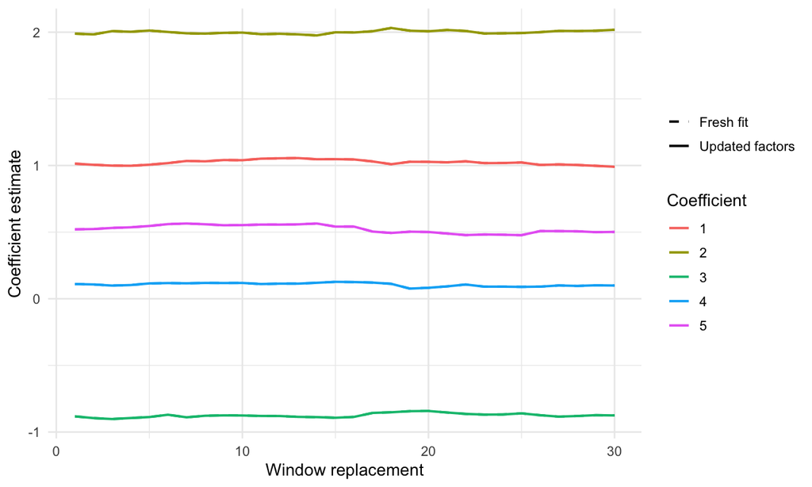

Figure 1: Coefficient estimates as the window advances. Solid lines use updated factors; dashed lines are fresh least-squares fits. The two computations agree to numerical precision.

```r
path_data <- rbind(
  data.frame(step = rep(seq_len(steps), p), coefficient = factor(rep(seq_len(p), each = steps)),
             estimate = as.vector(coef_update), method = "Updated factors"),
  data.frame(step = rep(seq_len(steps), p), coefficient = factor(rep(seq_len(p), each = steps)),
             estimate = as.vector(coef_fresh), method = "Fresh fit"))
ggplot2::ggplot(path_data, ggplot2::aes(step, estimate, colour = coefficient,
                                      linetype = method)) +
  ggplot2::geom_line(linewidth = .8) +
  ggplot2::scale_linetype_manual(values = c("Fresh fit" = "dashed", "Updated factors" = "solid")) +
  ggplot2::labs(x = "Window replacement", y = "Coefficient estimate", colour = "Coefficient",
                linetype = NULL) + ggplot2::theme_minimal(base_size = 12)
```

This example illustrates the algorithm, not a claim about universal speed or long-run stability. Over long sequences, monitor reconstruction or Gram errors and consider periodic refactorization. Maintaining only $R$ avoids storing $Q$, but this particular example retains the data window so that observations can be deleted and reference fits checked.

# 3 Least squares, ridge paths and model selection

The factors become statistically useful when they are connected to an estimation problem and to the predictions obtained from its solution. This chapter begins with ordinary least squares, where a coefficient vector can be checked against an independent QR fit, and then introduces ridge regularization. A ridge path shows how the estimates change with the penalty; cross-validation supplies a separate procedure for choosing among those candidate fits.

The construction of the design remains part of the model specification. These matrix interfaces do not insert an intercept or perform preprocessing automatically, so the examples make those choices explicit. Both ridge backends are checked against augmented-design QR calculations, allowing differences in model specification to be distinguished from differences between numerical implementations.

## 3.1 Least squares with predictions

Write the regression model as $y=D\theta+\varepsilon$, where $D=[\boldsymbol 1_n,X]$ includes an intercept and $\theta=(\alpha,\beta^\top)^\top$. A direct thin factorization $D=Q_D R_D$ gives the least-squares estimate through $R_D\widehat\theta=Q_D^\top y$. The fitted values are $D\widehat\theta$, while a new design with the same column definitions gives predictions $D_{\mathrm{test}}\widehat\theta$.

The model-fitting interface used here, `qrls(..., type = "QR")`, solves a normalized cross-product system internally. The example therefore checks its coefficients against both a direct factorization of D and `lm.fit()`. On this well-conditioned design the three routes should agree to numerical precision; the accuracy chapter examines why their agreement on such an example does not establish identical numerical behavior near singularity.

We generate six predictors, of which three have nonzero coefficients, together with an intercept. Observation noise means that fitted coefficients need not equal their generating values exactly. The independent test observations are reserved for assessing prediction after the model has been fitted.

```r
set.seed(2029)
n <- 160L
p <- 6L
n_test <- 400L
X <- matrix(rnorm(n * p), n, p)
X_test <- matrix(rnorm(n_test * p), n_test, p)
beta_true <- c(2, -1.5, .75, 0, 0, 0)
y <- drop(1 + X %*% beta_true + rnorm(n, sd = 1.5))
y_test <- drop(1 + X_test %*% beta_true + rnorm(n_test, sd = 1.5))
design <- cbind(intercept = 1, X)
design_test <- cbind(intercept = 1, X_test)
ols <- fastQR::qrls(y, design, X_test = design_test, type = "QR")
ols_factors <- fastQR::qr(design, complete = FALSE)
ols_projection <- crossprod(ols_factors$Q, y)
ols_explicit <- backsolve(ols_factors$R, ols_projection)
ols_derivation_error <- max(abs(ols$coeff - ols_explicit))
stopifnot(ols_derivation_error < 1e-10,
          max(abs(ols$coeff - lm.fit(design, y)$coefficients)) < 1e-10)
knitr::kable(data.frame(
  term = c("Intercept", paste0("x", seq_len(p))),
  truth = c(1, beta_true), estimate = as.numeric(ols$coeff)), digits = 4)
```

| term | truth | estimate |
| --- | --- | --- |
| Intercept | 1.00 | 1.1081 |
| x1 | 2.00 | 2.0667 |
| x2 | -1.50 | -1.3108 |
| x3 | 0.75 | 0.8603 |
| x4 | 0.00 | -0.0704 |
| x5 | 0.00 | -0.1605 |
| x6 | 0.00 | -0.0224 |

```r
ols_test_mse <- mean((y_test - drop(design_test %*% ols$coeff))^2)
ols_test_mse
```

```
## [1] 2.238406
```

The error on the independent test set estimates predictive performance; it is not the training residual variance. We compute the squared residual loss explicitly from predictions so that the quantity being reported is unambiguous.

Figure 2 compares the independent test responses with the predictions from the fitted model. The identity line represents exact prediction. Scatter around that line includes the new observation noise, so an accurate coefficient estimate does not make every test prediction coincide with its observed response.

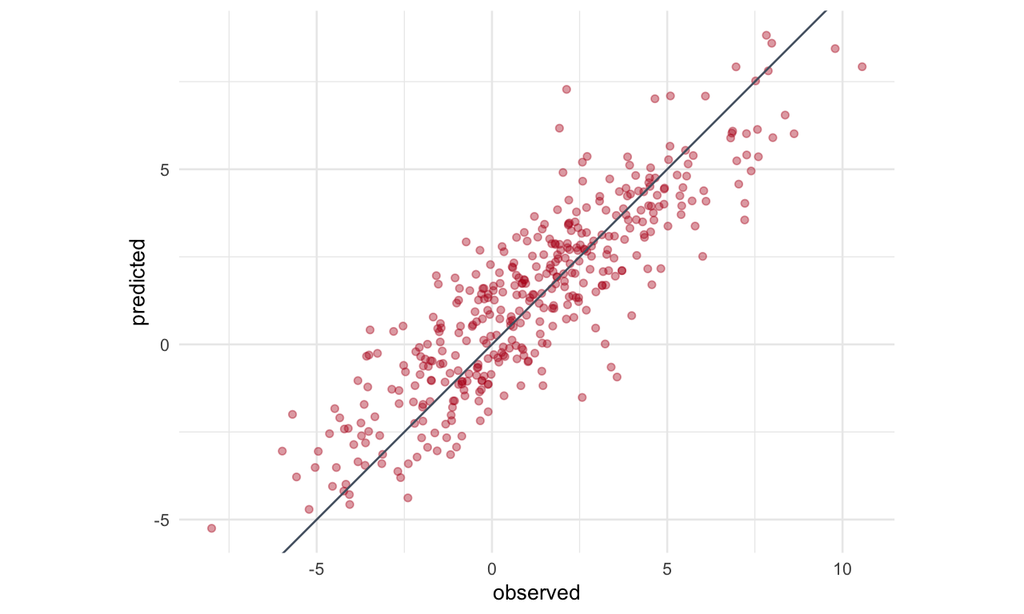

Figure 2: Independent test responses versus least-squares predictions. The diagonal is a reference line, not a fitted trend.

```r
ggplot2::ggplot(data.frame(observed = y_test,
                          predicted = drop(design_test %*% ols$coeff)),
                ggplot2::aes(observed, predicted)) +
  ggplot2::geom_point(alpha = .4, colour = "#b5121b") +
  ggplot2::geom_abline(slope = 1, intercept = 0, colour = "#526070") +
  ggplot2::coord_equal() + ggplot2::theme_minimal(base_size = 12)
```

## 3.2 Ridge: scaling the penalty and handling the intercept

For either backend of `qrridge()`, the coefficient vector solves
$$\widehat\beta_\lambda
=\arg\min_b\left\{\frac{1}{n}\|y-Xb\|_2^2+\lambda\|b\|_2^2\right\}
=(X^\top X+n\lambda I_p)^{-1}X^\top y.$$
Differentiating this criterion with respect to b gives
$$-\frac{2}{n}X^\top(y-Xb)+2\lambda b=0,$$
and hence the penalized system $(X^\top X+n\lambda I_p)\widehat\beta_\lambda=X^\top y$. A positive penalty adds curvature in every coefficient direction, making this system nonsingular even if the design has dependent columns. The inverse in the displayed expression describes the estimator mathematically; the implementations obtain it through factorizations and solves.

### 3.2.1 The two numerical routes

In the `QR` backend, define $A_\lambda=X^\top X/n+\lambda I_p$ and $h=X^\top y$. The routine factorizes $A_\lambda=Q_A R_A$, forms $Q_A^\top h/n$ and solves the upper triangular system with $R_A$. The factorization is therefore of the normalized penalized system, rather than of X itself.

The `R` backend uses the augmented design $\widetilde X=[X^\top,\sqrt{n\lambda}I_p]^\top$ to obtain a triangular factor $\widetilde R$ satisfying $\widetilde R^\top\widetilde R=X^\top X+n\lambda I_p$. The coefficients follow from
$$\widetilde R^\top c=h,\qquad
\widetilde R\widehat\beta_\lambda=c.$$
These routes have the same exact-arithmetic solution, while their intermediate factors have different meanings. The examples compare their coefficients with an independent augmented-design QR solve, rather than comparing their R entries as though they were the same factorization.

The factor n follows from normalizing the data loss by the number of observations. Replicating all observations leaves this criterion, and therefore the estimate at a fixed penalty, unchanged. In a validation fold the same convention uses the number of training observations, not the size of the full dataset.

### 3.2.2 Centering, scaling and coefficient interpretation

Here `lambda` is **a scalar**. We build a path by calling the function once per grid value. All supplied columns are penalized. To leave the intercept unpenalized, center the response and predictors, estimate the slopes, and reconstruct the intercept. We also scale predictors using training-set standard deviations so that a common penalty has a comparable interpretation across columns.

Let $\bar x_j$ and $s_j$ denote the training mean and standard deviation of predictor j, and define $Z_{ij}=(X_{ij}-\bar x_j)/s_j$. Fitting the centered response on Z produces standardized coefficients $\widehat\gamma_\lambda$. The original-scale slopes and intercept are recovered through
$$\widehat\beta_{\lambda,j}=\widehat\gamma_{\lambda,j}/s_j,
\qquad
\widehat\alpha_\lambda=\bar y-\sum_j\bar x_j\widehat\beta_{\lambda,j}.$$
Thus a new prediction can be obtained either from the standardized design with the training means and scales, or from the original predictors with these recovered coefficients. The penalty acts on the standardized coefficients, which is why changing predictor units without an explicit scaling convention can change the fit.

```r
x_mean <- colMeans(X)
x_scale <- apply(X, 2, sd)
y_mean <- mean(y)
Z <- sweep(sweep(X, 2, x_mean, "-"), 2, x_scale, "/")
y_centered <- y - y_mean
lambda <- exp(seq(log(1e-4), log(10), length.out = 50L))
path_standardized <- vapply(lambda, function(lam) {
  as.numeric(fastQR::qrridge(y_centered, Z, lambda = lam, type = "QR")$coeff)
}, numeric(p))
path_triangular <- vapply(lambda, function(lam) {
  as.numeric(fastQR::qrridge(y_centered, Z, lambda = lam, type = "R")$coeff)
}, numeric(p))
stopifnot(max(abs(path_standardized - path_triangular)) < 1e-10)
path_slopes <- sweep(path_standardized, 1, x_scale, "/")
path_intercept <- y_mean - drop(crossprod(x_mean, path_slopes))

# Independent augmented-design QR calculation at one grid value.
j <- 20L
reference <- qr.coef(base::qr(rbind(Z, sqrt(n * lambda[j]) * diag(p))),
                     c(y_centered, rep(0, p)))
stopifnot(max(abs(path_standardized[, j] - reference)) < 1e-10)
```

The R-only calculation at one path value can also be checked directly from its returned triangular factor. The inner `forwardsolve()` reconstructs the response coordinates, and the following `backsolve()` returns the coefficients. The additional rows in the augmented QR reference contain zeros in the response because they encode only the penalty.

```r
ridge_R_fit <- fastQR::qrridge(y_centered, Z, lambda[j], type = "R")
ridge_rhs <- crossprod(Z, y_centered)
ridge_coordinates <- forwardsolve(t(ridge_R_fit$R), ridge_rhs)
ridge_explicit <- backsolve(ridge_R_fit$R, ridge_coordinates)
ridge_manual_error <- max(abs(ridge_explicit - path_triangular[, j]))
stopifnot(ridge_manual_error < 1e-10)
```

Figure 3 follows the fitted slopes as the penalty increases. Expressing the coefficients on the original predictor scale makes their statistical interpretation consistent with the data-generating model, while the logarithmic penalty axis reveals changes across several orders of magnitude. Agreement between the two numerical backends is checked before the paths are drawn.

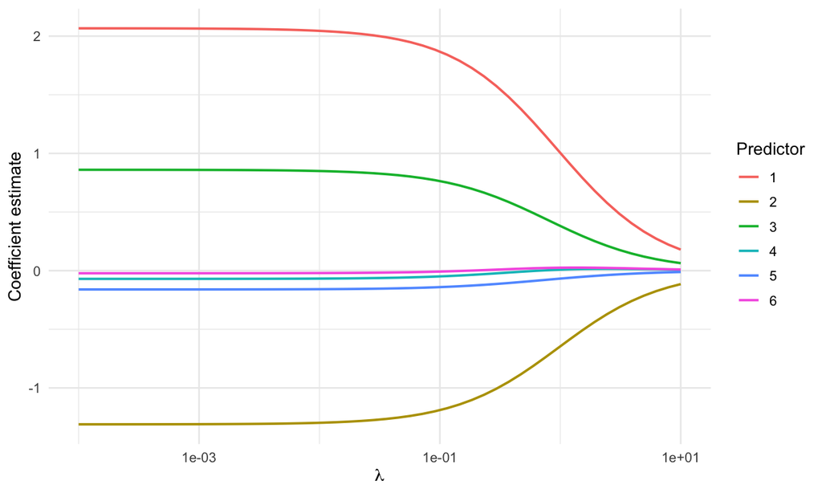

Figure 3: Ridge slopes on their original predictor scale, plotted against a logarithmic penalty grid. The coefficients change continuously with the penalty; ridge does not generally create an exactly sparse fit.

```r
path_table <- data.frame(lambda = rep(lambda, each = p),
                         coefficient = factor(rep(seq_len(p), length(lambda))),
                         estimate = as.vector(path_slopes))
ggplot2::ggplot(path_table, ggplot2::aes(lambda, estimate, colour = coefficient)) +
  ggplot2::geom_line(linewidth = .8) + ggplot2::scale_x_log10() +
  ggplot2::labs(x = expression(lambda), y = "Coefficient estimate", colour = "Predictor") +
  ggplot2::theme_minimal(base_size = 12)
```

## 3.3 Cross-validation with preprocessing inside each fold

A coefficient vector at a fixed penalty minimizes training loss plus a penalty term. Choosing the penalty is a separate calculation, for which the relevant target is prediction on observations not used to obtain those coefficients. Divide the training sample into validation sets $\mathcal V_1,\ldots,\mathcal V_K$, and let $\mathcal T_k$ contain the remaining observations for fold k. A candidate penalty is fitted on $\mathcal T_k$ and evaluated on $\mathcal V_k$.

The explicit loop below records a squared prediction error for every validation observation and averages those errors across the full sample,
$$\mathrm{CV}(\lambda)
=\frac{1}{n}\sum_{k=1}^K\sum_{i\in\mathcal V_k}
\left(y_i-\widehat y_i^{(-k)}(\lambda)\right)^2.$$
The same fold assignment is retained for every candidate penalty. Means, standard deviations and the response mean are estimated from $\mathcal T_k$ alone, then applied to the held-out predictors. This reproduces the information available when predicting a genuinely new observation and prevents validation values from influencing the preprocessing used to fit that fold.

After selecting the smallest validation error, the final coefficient vector is taken from the path fitted on the full training sample. Its preprocessing uses the full training means and scales, as it should at this refitting stage. The independent test set remains outside both the fold calculations and the penalty selection.

```r
set.seed(2030)
K <- 5L
fold <- sample(rep(seq_len(K), length.out = n))
squared_error <- matrix(NA_real_, n, length(lambda))
for (k in seq_len(K)) {
  train <- fold != k
  valid <- !train
  mu <- colMeans(X[train, , drop = FALSE])
  sc <- apply(X[train, , drop = FALSE], 2, sd)
  ybar <- mean(y[train])
  Z_train <- sweep(sweep(X[train, , drop = FALSE], 2, mu, "-"), 2, sc, "/")
  Z_valid <- sweep(sweep(X[valid, , drop = FALSE], 2, mu, "-"), 2, sc, "/")
  for (j in seq_along(lambda)) {
    b <- fastQR::qrridge(y[train] - ybar, Z_train,
                         lambda = lambda[j], type = "QR")$coeff
    prediction <- ybar + drop(Z_valid %*% b)
    squared_error[valid, j] <- (y[valid] - prediction)^2
  }
}
cv_mse <- colMeans(squared_error)
best <- which.min(cv_mse)
lambda_selected <- lambda[best]
selected_prediction <- path_intercept[best] + drop(X_test %*% path_slopes[, best])
knitr::kable(data.frame(
  method = c("Least squares", "CV-selected ridge"),
  test_MSE = c(ols_test_mse, mean((y_test - selected_prediction)^2))), digits = 4)
```

| method | test_MSE |
| --- | --- |
| Least squares | 2.2384 |
| CV-selected ridge | 2.2378 |

```r
lambda_selected
```

```
## [1] 0.001676833
```

The test responses are used only after selection. A single simulation need not favor ridge over least squares. Cross-validation chooses among the candidate penalties; it does not guarantee that the selected fit outperforms every alternative on new data. If the selected value lies at a grid endpoint, consider extending the grid.

The validation curve in Figure 4 summarizes the prediction loss over the candidate penalties. Its minimum identifies the value used for the final fit, with the dashed line locating that choice on the same grid. The curve concerns held-out prediction after fold-specific preprocessing; it is not the training loss minimized when estimating the coefficients.

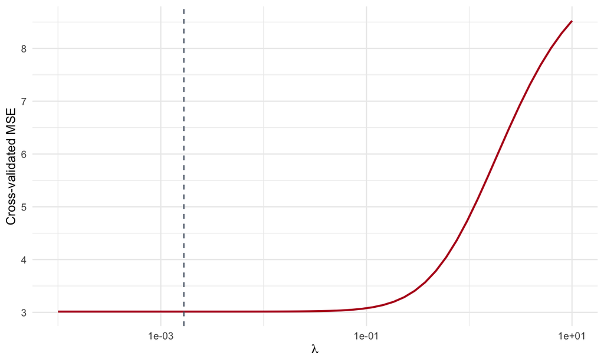

Figure 4: Validation mean squared error along the penalty grid. The dashed line marks the minimum on this grid.

```r
ggplot2::ggplot(data.frame(lambda, MSE = cv_mse), ggplot2::aes(lambda, MSE)) +
  ggplot2::geom_line(colour = "#b5121b", linewidth = .9) +
  ggplot2::geom_vline(xintercept = lambda_selected, linetype = "dashed", colour = "#526070") +
  ggplot2::scale_x_log10() + ggplot2::labs(x = expression(lambda), y = "Cross-validated MSE") +
  ggplot2::theme_minimal(base_size = 12)
```

## 3.4 Effective degrees of freedom along the ridge path

For a fixed design, fixed preprocessing and fixed $\lambda$, ridge is linear in $y$. If $d_j$ are the singular values of the centered, standardized design $Z$, the effective degrees of freedom including the unpenalized intercept are
$$\mathrm{df}(\lambda)=1+\sum_{j=1}^p\frac{d_j^2}{d_j^2+n\lambda}.$$
To see where this expression comes from, write the thin singular value decomposition $Z=U_Z D_Z V_Z^\top$, with diagonal entries $d_j$ in $D_Z$. For the centered response $y_c=y-\bar y\boldsymbol 1_n$, the centered fitted values are
$$\widehat y_c
=H_\lambda y_c,\qquad
H_\lambda
=U_Z\operatorname{diag}\left(\frac{d_j^2}{d_j^2+n\lambda}\right)U_Z^\top.$$
Each orthogonal data direction therefore contributes a shrinkage multiplier $d_j^2/(d_j^2+n\lambda)$ to the fitted-value map. The trace of this matrix is the sum of those multipliers. Because Z has centered columns, the separate intercept adds the projection onto the constant direction and contributes one additional degree of freedom.

For a full-column-rank Z, the total approaches $p+1$ as the penalty tends to zero and approaches one as it tends to infinity. These limits describe the unpenalized fit and the intercept-only limit. They do not require every coefficient on the original predictor scale to decrease monotonically when predictors are correlated.

The code computes this fixed-penalty trace explicitly, rather than reading the package’s legacy residual-dimension field `df`. Substituting a penalty selected from the responses locates a fit on the curve, but the trace of that candidate alone does not include the additional response dependence of the selection rule.

Figure 5 expresses the same regularization path in terms of effective model complexity. Increasing the penalty reduces the contribution of each penalized direction, while the unpenalized intercept contributes one degree of freedom throughout. The dashed line locates the selected penalty without incorporating the additional response dependence of the selection procedure into this fixed-penalty formula.

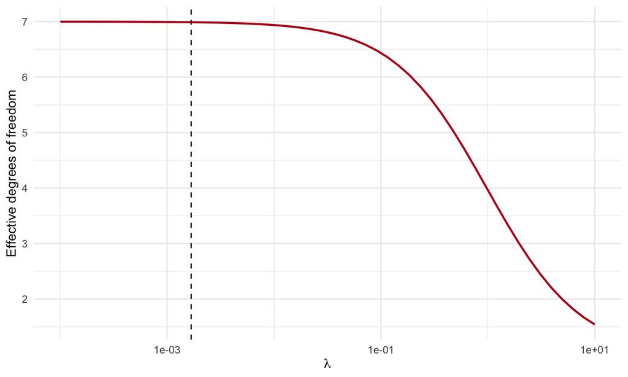

Figure 5: Effective degrees of freedom for each fixed ridge penalty, including the unpenalized intercept. The dashed line marks the cross-validated penalty; the curve describes fixed-penalty fits.

```r
d2 <- svd(Z, nu = 0, nv = 0)$d^2
df_path <- vapply(lambda, function(lam) 1 + sum(d2 / (d2 + n * lam)), numeric(1))
stopifnot(all(diff(df_path) <= 0), all(df_path >= 1), all(df_path <= p + 1))
ggplot2::ggplot(data.frame(lambda, df = df_path), ggplot2::aes(lambda, df)) +
  ggplot2::geom_line(colour = "#b5121b", linewidth = .9) + ggplot2::scale_x_log10() +
  ggplot2::geom_vline(xintercept = lambda_selected, linetype = "dashed") +
  ggplot2::labs(x = expression(lambda), y = "Effective degrees of freedom") +
  ggplot2::theme_minimal(base_size = 12)
```

## 3.5 Multiple responses

With $Y\in\mathbb R^{n\times q}$, the model has a coefficient matrix $B\in\mathbb R^{p_D\times q}$, where $p_D$ is the number of columns in the supplied design D. The least-squares loss is $\|Y-DB\|_F^2$, the sum of the q response-specific squared losses. A direct factorization $D=Q_D R_D$ yields
$$C=Q_D^\top Y,\qquad R_D\widehat B=C.$$
The columns of C are projected response vectors. One triangular factor is reused to solve for all coefficient columns, so the common design does not need to be factorized separately for each outcome. The example checks `qrmls()` against both that direct calculation and a base-R QR fit.

```r
set.seed(2031)
Y <- cbind(y, drop(-.5 + X %*% c(0, 1, 0, -1, 0, .5) + rnorm(n)))
multivariate <- fastQR::qrmls(Y, design, type = "QR")
reference <- qr.coef(base::qr(design), Y)
multi_direct <- backsolve(ols_factors$R, crossprod(ols_factors$Q, Y))
multi_direct_error <- max(abs(multivariate$coeff - multi_direct))
stopifnot(multi_direct_error < 1e-10,
          max(abs(multivariate$coeff - reference)) < 1e-10)
knitr::kable(as.matrix(multivariate$coeff), digits = 4,
             col.names = c("Response 1", "Response 2"))
```

| Response 1 | Response 2 |
| --- | --- |
| 1.1081 | -0.5143 |
| 2.0667 | -0.0096 |
| -1.3108 | 1.1742 |
| 0.8603 | -0.0503 |
| -0.0704 | -0.9931 |
| -0.1605 | -0.0918 |
| -0.0224 | 0.2954 |

## 3.6 Native cross-validation on a supplied design

The packaged interfaces select a penalty for the design matrix supplied to them. They do not center the response, standardize predictors within folds or treat a column of ones separately. Consequently, the following fit penalizes the intercept column in `design`. It answers a different model-selection question from the preceding example, where preprocessing is repeated within each fold and the intercept is unpenalized.

The native interfaces generate random folds from the supplied seed, and return their labels rather than accepting a user-supplied fold assignment. The independent simulated observations used here match that resampling setup. An explicit validation loop leaves the training and validation sets under the analyst’s control when a different prediction design is required, such as a chronological split of ordered observations.

Each training fit minimizes its own normalized loss, with the number of training observations multiplying the penalty in the normal equations. The returned `foldid` makes the split explicit. The reported curve averages held-out squared errors equally across folds; when fold sizes differ, this need not equal a pooled average across all validation observations.

```r
native_qr <- fastQR::qrridge_cv(y, design, lambda, k = 5L, seed = 2032L,
                                X_test = design_test, type = "QR")
native_r <- fastQR::qrridge_cv(y, design, lambda, k = 5L, seed = 2032L,
                               X_test = design_test, type = "R")
stopifnot(identical(native_qr$foldid, native_r$foldid),
          max(abs(native_qr$mse - native_r$mse)) < 1e-10,
          max(abs(native_qr$coeff - native_r$coeff)) < 1e-10)

# Reconstruct the entire validation curve independently.
native_reference_mse <- vapply(lambda, function(lam) {
  mean(vapply(sort(unique(native_qr$foldid)), function(k) {
    train <- native_qr$foldid != k
    valid <- !train
    nt <- sum(train)
    A <- rbind(design[train, , drop = FALSE],
               sqrt(nt * lam) * diag(ncol(design)))
    b <- qr.coef(base::qr(A), c(y[train], rep(0, ncol(design))))
    mean((y[valid] - drop(design[valid, , drop = FALSE] %*% b))^2)
  }, numeric(1)))
}, numeric(1))
stopifnot(max(abs(as.numeric(native_qr$mse) - native_reference_mse)) < 1e-10)
knitr::kable(data.frame(
  backend = c("QR", "R"),
  selected_lambda = c(native_qr$lambda_min, native_r$lambda_min),
  validation_MSE = c(native_qr$mse_min, native_r$mse_min),
  test_MSE = c(mean((y_test - native_qr$predicted)^2),
               mean((y_test - native_r$predicted)^2))), digits = 5,
  caption = "Native cross-validation with a penalized intercept column.")
```

Native cross-validation with a penalized intercept column.

| backend | selected_lambda | validation_MSE | test_MSE |
| --- | --- | --- | --- |
| QR | 0.02223 | 2.87428 | 2.22877 |
| R | 0.02223 | 2.87428 | 2.22877 |

The final coefficients are estimated again on the full training sample at the selected penalty. The `mse_min_ind` field retains a zero-based index for compatibility; `lambda_min` gives the selected value directly. For the `R` backend, an explicit orthogonal factor is neither needed nor returned.

## 3.7 Ridge with multiple responses

Ridge retains the shared-system structure for several outcomes. Differentiating $\|Y-DB\|_F^2/n+\lambda\|B\|_F^2$ gives
$$(D^\top D+n\lambda I_{p_D})\widehat B_\lambda=D^\top Y.$$
The right-hand side has q columns; each is processed using the same penalized factorization. The augmented reference stacks $\sqrt{n\lambda}I_{p_D}$ below D and a $p_D\times q$ zero matrix below Y, turning the penalized calculation into ordinary multivariate least squares.

The native validation score averages squared prediction errors over held-out rows and response columns within each fold, then averages the fold scores. Averaging over responses multiplies their summed prediction loss by the fixed factor $1/q$, which does not change the ordering of candidate penalties for that response set. Different response units still change the relative contribution of the outcomes, so any desired response scaling must be specified explicitly and fitted within the training portions of the validation procedure.

```r
multi_qr <- fastQR::qrmridge_cv(Y, design, lambda, k = 5L, seed = 2032L,
                                X_test = design_test, type = "QR")
multi_r <- fastQR::qrmridge_cv(Y, design, lambda, k = 5L, seed = 2032L,
                               X_test = design_test, type = "R")
A <- rbind(design, sqrt(n * multi_qr$lambda_min) * diag(ncol(design)))
B_reference <- qr.coef(base::qr(A), rbind(Y, matrix(0, ncol(design), ncol(Y))))
stopifnot(max(abs(multi_qr$coeff - B_reference)) < 1e-10,
          max(abs(multi_r$coeff - B_reference)) < 1e-10,
          max(abs(multi_qr$mse - multi_r$mse)) < 1e-10,
          max(abs(multi_qr$predicted - design_test %*% B_reference)) < 1e-10,
          !anyDuplicated(names(multi_qr)), !anyDuplicated(names(multi_r)))
knitr::kable(data.frame(
  backend = c("QR", "R"),
  selected_lambda = c(multi_qr$lambda_min, multi_r$lambda_min),
  validation_MSE = c(multi_qr$mse_min, multi_r$mse_min),
  maximum_coefficient_error = c(max(abs(multi_qr$coeff - B_reference)),
                                max(abs(multi_r$coeff - B_reference)))),
  digits = 6, caption = "Multiple-response ridge checked against an independent QR fit.")
```

Multiple-response ridge checked against an independent QR fit.

| backend | selected_lambda | validation_MSE | maximum_coefficient_error |
| --- | --- | --- | --- |
| QR | 0.028118 | 2.020752 | 0 |
| R | 0.028118 | 2.020752 | 0 |

The cross-products are available as `XTX` and `XTY`; `XTy` is retained as an alias of `XTY`. The returned `df` field is a legacy residual-dimension diagnostic, rather than the effective ridge degrees of freedom derived earlier. Likewise, residual variance and covariance estimates divided by `n-p` are diagnostics, not unbiased ridge variance estimators.

# 4 Choosing the ridge penalty by marginal likelihood

Cross-validation selects a penalty by measuring predictive performance on observations omitted from fitting. A probability model offers another route: the coefficient vector can be integrated out, leaving a marginal likelihood for the regularization parameter. This chapter develops that construction explicitly, including the normalization terms that would be lost by treating a penalized residual sum of squares as a likelihood on its own.

We first describe the Gaussian model and derive its marginal likelihood, then explain how the variance and penalty are estimated. The implementation uses a single singular value decomposition to avoid repeating a matrix factorization at every candidate penalty. An independent QR calculation verifies the resulting coefficients. The concluding simulations compare this empirical Bayes procedure with an efficient cross-validation calculation on both tall and wide designs, under a dense Gaussian signal and a sparse signal that departs from the assumed coefficient distribution.

Gaussian marginal likelihood and hyperparameter selection are treated in Rasmussen and Williams (2006), Chapters 2 and 5. For work specifically on fast marginal likelihood selection of ridge parameters using singular values, see Karabatsos (2015). The construction below fixes its own prior and profiles the noise variance; it should not be read as a reproduction of every prior or algorithm in those references.

## 4.1 A Gaussian model whose posterior mean is ridge

Let $X\in\mathbb R^{n\times p}$ be fixed, and suppose
$$y\mid\beta,\sigma^2\sim N_n(X\beta,\sigma^2I_n),\qquad
\beta\mid\sigma^2,\lambda\sim
N_p\!\left(0,\frac{\sigma^2}{n\lambda}I_p\right),
\qquad \lambda>0.$$
The prior has the same variance in every coefficient direction. Its meaning consequently depends on the units of the predictors: rescaling a column without transforming the prior changes the model. The examples use predictors generated on a common scale, with a known zero intercept. The package does not insert an intercept or standardize columns automatically.

Set $\alpha=n\lambda$ and $A_\alpha=X^\top X+\alpha I_p$. Multiplying the likelihood and prior gives a quadratic exponent proportional to
$$\|y-X\beta\|_2^2+\alpha\|\beta\|_2^2.$$
Completing the square yields
$$\|y-X\beta\|_2^2+\alpha\|\beta\|_2^2
=q_\alpha+(\beta-\widehat\beta_\alpha)^\top A_\alpha
(\beta-\widehat\beta_\alpha),$$
where
$$\widehat\beta_\alpha=A_\alpha^{-1}X^\top y,\qquad
q_\alpha=\|y-X\widehat\beta_\alpha\|_2^2+
\alpha\|\widehat\beta_\alpha\|_2^2.$$
Thus the conditional posterior is
$$\beta\mid y,\sigma^2,\lambda\sim
N_p(\widehat\beta_\alpha,\sigma^2 A_\alpha^{-1}).$$
Its mean and mode coincide with the ridge coefficients for the normalized criterion used by `qrridge()`. The inverse notation specifies the mathematical result; the numerical calculations below use decompositions and solves.

## 4.2 Integrating the coefficients

Integration means evaluating the density of the observed response after averaging over the coefficient prior:
$$p(y\mid\sigma^2,\lambda)=
\int_{\mathbb R^p}p(y\mid\beta,\sigma^2)
p(\beta\mid\sigma^2,\lambda)\,\mathrm d\beta.$$
Using the completed square, the Gaussian integral contributes $(2\pi\sigma^2)^{p/2}|A_\alpha|^{-1/2}$. Combining this factor with the likelihood and prior normalizations gives
$$p(y\mid\sigma^2,\lambda)
=(2\pi\sigma^2)^{-n/2}\alpha^{p/2}|A_\alpha|^{-1/2}
\exp\!\left(-\frac{q_\alpha}{2\sigma^2}\right).$$
The determinant factor matters: it changes when the prior becomes more or less concentrated. Omitting it would not maximize this marginal likelihood.

The same result follows directly from adding independent Gaussian random vectors. Writing
$$C_\lambda=I_n+\frac{XX^\top}{n\lambda},$$
we obtain
$$y\mid\sigma^2,\lambda\sim N_n(0,\sigma^2 C_\lambda).$$
The determinant identity and quadratic-form identity are
$$\log|C_\lambda|=\log|A_\alpha|-p\log\alpha,
\qquad y^\top C_\lambda^{-1}y=q_\alpha.$$
If $R^\top R=A_\alpha$, the first quantity can also be evaluated as
$$\log|C_\lambda|=2\sum_{j=1}^p\log|R_{jj}|-p\log\alpha.$$
This connects the criterion to the augmented QR factors used in the previous chapter. For the quadratic form, evaluating the penalized residual expression is preferable to subtracting the nearly equal quantities $y^\top y$ and $y^\top X\widehat\beta_\alpha$ when the fit is very close.

## 4.3 Profiling the variance and optimizing the penalty

For a given $\lambda$, differentiation of the marginal log likelihood with respect to $\sigma^2$ gives
$$\widehat\sigma^2_\lambda=\frac{q_\alpha}{n}.$$
This is the maximum-likelihood estimate under the marginal model. It is not the residual diagnostic based on $n-p$, nor a correction based on the smoother trace. Inserting it into the negative log likelihood leaves, up to a constant independent of $\lambda$,
$$F(\lambda)=\frac12\left\{
n\log\!\left(\frac{q_\alpha}{n}\right)+\log|C_\lambda|
\right\}.$$
We minimize this one-dimensional function and then evaluate the ridge posterior mean at the selected penalty. The coefficients have been integrated out, while $\sigma^2$ has been profiled and $\lambda$ estimated. No prior on $\lambda$ is integrated in this procedure, and no claim of fully Bayesian hyperparameter uncertainty is implied.

Optimization is performed on $t=\log\lambda$, so every evaluated finite penalty is positive. A coarse grid locates candidate local minima; bounded searches refine their neighboring intervals, and the endpoints are compared explicitly. A finite grid cannot certify a global optimum for every possible response. A returned lower-bound solution calls for inspecting and, where appropriate, extending the search range rather than describing it as an interior optimum.

The implementation also evaluates the limiting model $\lambda\to\infty$. In that limit the coefficient prior collapses at zero, $C_\lambda\to I_n$, and the fitted mean is zero. A data set can support this limit. Reporting it explicitly avoids inventing a large but arbitrary finite optimum. At the other extreme, small penalties can produce weakly identified or boundary behavior, especially in saturated or nearly interpolating settings; positivity alone does not guarantee a well-separated interior maximum.

An unknown unpenalized intercept requires an additional treatment of the mean, for example through generalized least-squares profiling or a restricted-likelihood construction with its corresponding adjustment. Simply centering the response and retaining every term of the known-mean likelihood without justification would change the inferential argument. The present implementation uses the explicitly stated known-zero-mean model and does not implement REML.

### 4.3.1 The score equation and the conditional smoother trace

The singular values also give an interpretable derivative of the profile criterion. With $t=\log\lambda$ and $\alpha=n\exp(t)$, define
$$\dot q_\alpha=\sum_{j=1}^r z_j^2
\frac{\alpha d_j^2}{(d_j^2+\alpha)^2},\qquad
d_\alpha=\sum_{j=1}^r\frac{d_j^2}{d_j^2+\alpha}.$$
Differentiating the profile criterion gives
$$\frac{\mathrm d F}{\mathrm d t}
=\frac12\left(\frac{n\dot q_\alpha}{q_\alpha}-d_\alpha\right).$$
Here $d_\alpha$ is the trace of the ridge smoother at a fixed penalty. An interior empirical Bayes optimum balances these two terms. This identity is useful for checking an optimizer, but it does not justify replacing the marginal-model variance estimate $q_\alpha/n$ with a residual degrees-of-freedom adjustment. The numerical checks below compare the analytic derivative with a centered finite difference.

## 4.4 A single decomposition for the entire objective

Let $X=UDV^\top$ be an economy singular value decomposition with $r=\min(n,p)$ columns in $U$, and write $z=U^\top y$ and $y_\perp=y-Uz$. Then
$$\log|C_\lambda|=\sum_{j=1}^r\log\!\left(1+\frac{d_j^2}{\alpha}\right),
\qquad
q_\alpha=\|y_\perp\|_2^2+
\sum_{j=1}^r z_j^2\frac{\alpha}{d_j^2+\alpha}.$$
These formulas remain valid for zero singular values and for $p>n$. Evaluating the residual component directly avoids obtaining its squared norm by subtraction. The logarithm is computed with `log1p()`, which preserves accuracy for small arguments. After preparation, evaluating a new penalty uses scalar operations on the stored singular values and projected response rather than a fresh decomposition.

The posterior mean is recovered as
$$\widehat\beta_\alpha=V\,\operatorname{diag}
\!\left(\frac{d_j}{d_j^2+\alpha}\right)z.$$
This is a computational alternative to repeatedly refactorizing the augmented design. The SVD is included in the measured cost of penalty selection below; it is not treated as an available free input.

```r
evidence_X <- evidence_results$demo$X
evidence_y <- evidence_results$demo$y
evidence_fit <- evidence_results$demo$fit
knitr::kable(data.frame(lambda = evidence_fit$lambda,
                        alpha = evidence_fit$alpha,
                        sigma2 = evidence_fit$sigma2,
                        status = evidence_fit$status), digits = 5,
             caption = "Empirical Bayes penalty and marginal-model variance estimate for the reproducible example.")
```

Empirical Bayes penalty and marginal-model variance estimate for the reproducible example.

| lambda | alpha | sigma2 | status |
| --- | --- | --- | --- |
| 0.0709 | 7.08978 | 0.95447 | interior |

```r
# In a new analysis, after sourcing scripts/ridge-evidence.R:
# evidence_fit <- ridge_evidence_fit(X, y)
```

The estimated penalty can be passed directly to the package’s normalized ridge interface when it is finite. The following comparison checks that the posterior mean computed from singular values agrees with the augmented-factor implementation.

```r
if (is.finite(evidence_fit$lambda)) {
  evidence_native <- fastQR::qrridge(evidence_y, evidence_X,
                                    evidence_fit$lambda, type = "R")
  evidence_native_error <- max(abs(evidence_native$coeff - evidence_fit$coeff))
  stopifnot(evidence_native_error < 1e-10)
  evidence_native_error
}
```

```
## [1] 1.94289e-15
```

Figure 6 shows how the profile criterion changes with the penalty. The plotted ordinate subtracts the smallest displayed value for readability; this has no effect on the estimated minimum. A nearly flat region indicates that noticeably different penalties can have similar marginal support.

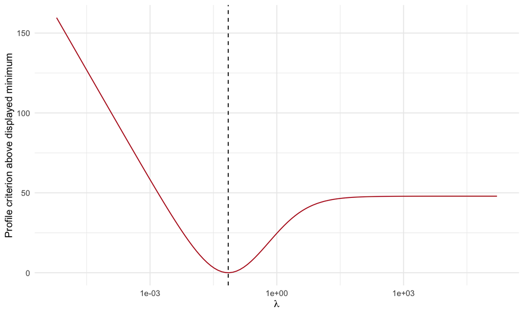

Figure 6: Profile negative marginal log likelihood as a function of the normalized ridge penalty, after profiling the noise variance. A vertical line marks the selected penalty when it is finite. The criterion is shifted by a constant for display.

```r
evidence_curve <- evidence_fit$curve
evidence_curve$relative_score <- evidence_curve$score - min(evidence_curve$score)
evidence_plot <- ggplot2::ggplot(evidence_curve, ggplot2::aes(lambda, relative_score)) +
  ggplot2::geom_line(colour = "#b5121b") + ggplot2::scale_x_log10() +
  ggplot2::labs(x = expression(lambda), y = "Profile criterion above displayed minimum") +
  ggplot2::theme_minimal(base_size = 11)
if (is.finite(evidence_fit$lambda)) evidence_plot <- evidence_plot +
  ggplot2::geom_vline(xintercept = evidence_fit$lambda, linetype = 2)
evidence_plot
```

## 4.5 Independent numerical checks

The criterion is verified against a direct Cholesky factorization of the response covariance $C_\lambda$ at several positive penalties. The coefficient calculation is checked against QR of the augmented design with an orthogonally transformed response. A further identity check compares $q_\alpha$ with the sum of squared residuals and the coefficient penalty. These calculations use different numerical representations of the same model.

```r
evidence_check_table <- evidence_results$checks
evidence_check_table[, -1] <- lapply(evidence_check_table[, -1],
  function(x) formatC(x, format = "e", digits = 2))
knitr::kable(evidence_check_table, row.names = FALSE,
 caption = "Agreement of the spectral marginal-likelihood calculation with dense-covariance and augmented-QR references.")
```

Agreement of the spectral marginal-likelihood calculation with dense-covariance and augmented-QR references.

| lambda | quadratic_error | determinant_error | coefficient_error | derivative_error | penalized_identity_error |
| --- | --- | --- | --- | --- | --- |
| 0.001 | 1.54e-14 | 2.76e-15 | 2.22e-15 | 2.45e-09 | 8.55e-16 |
| 0.100 | 0.00e+00 | 1.59e-16 | 1.80e-15 | 5.66e-10 | 0.00e+00 |
| 2.000 | 5.24e-16 | 2.27e-16 | 6.52e-16 | 3.43e-10 | 7.87e-16 |

## 4.6 Comparing marginal likelihood and cross-validation

Both selectors operate on the same training samples and use the same predictor units. The simulation considers $(n,p)=(100,40)$ and $(60,100)$, with independent standard-normal predictors and unit noise variance. In the dense scenario, coefficients are generated independently from $N(0,4/p)$, which matches the spherical prior structure. In the sparse scenario, three coefficients equal two and the remaining coefficients are zero. The latter intentionally departs from that prior. Five independently seeded training samples are generated for each setting, and each sample has an independent test set of four hundred observations.

For cross-validation, five training folds each receive their own SVD, reused over a common grid of thirty-one penalties from $10^{-4}$ to $10^2$. The training criterion uses the actual training size $n_{\rm train}\lambda$, and the validation errors are averaged across folds. After selection, a full-data decomposition provides the coefficients. The spectral CV calculation is checked against `qrridge_cv()` using the same fold assignment; its maximum discrepancy is 5.11e-15.

This efficient CV baseline avoids attributing an advantage to marginal likelihood merely because the competing implementation repeats a decomposition at every penalty. Both timing measurements include selection and the final coefficient calculation, with warm-up and three calibrated repetitions. Test-data generation and evaluation are outside the timed regions. The empirical Bayes search is continuous within refined log-penalty intervals, whereas CV selects from a specified finite grid; the two methods also target different statistical criteria.

```r
knitr::kable(evidence_summary, digits = 4, row.names = FALSE,
 caption = "Median test-response MSE, mean-prediction MSE and selection time across five simulated training samples per setting. Timings include the necessary decompositions and coefficient recovery.")
```

Median test-response MSE, mean-prediction MSE and selection time across five simulated training samples per setting. Timings include the necessary decompositions and coefficient recovery.

| n | p | signal | method | test_mse | mean_prediction_mse | selection_ms |
| --- | --- | --- | --- | --- | --- | --- |
| 100 | 40 | Dense Gaussian | CV | 1.4999 | 0.6015 | 2.3125 |
| 60 | 100 | Dense Gaussian | CV | 3.1738 | 2.2093 | 3.8750 |
| 100 | 40 | Sparse coefficients | CV | 1.7253 | 0.6749 | 2.3125 |
| 60 | 100 | Sparse coefficients | CV | 6.3302 | 5.2942 | 3.8750 |
| 100 | 40 | Dense Gaussian | evidence | 1.4847 | 0.6030 | 0.6875 |
| 60 | 100 | Dense Gaussian | evidence | 3.2351 | 2.1852 | 0.9375 |
| 100 | 40 | Sparse coefficients | evidence | 1.7136 | 0.6534 | 0.7031 |
| 60 | 100 | Sparse coefficients | evidence | 6.3284 | 5.2918 | 0.9375 |

In these simulations, marginal-likelihood selection is computationally faster: its median selection time is between 3.3 and 4.1 times smaller than that of the efficient five-fold CV implementation, depending on the design and signal scenario. Both costs include the required decompositions and recovery of the selected coefficients. This timing result compares two different selection criteria; it is not evidence that the empirical Bayes selector has uniformly lower predictive error. The paired test-set results below show the predictive comparison separately.

Figure 7 retains the individual simulation results, so the variability hidden by a table of medians remains visible. The test-response error includes irreducible observation noise; the separate mean-prediction error in the table compares predictions with the known conditional mean. The small simulation is illustrative and does not establish that one selector dominates across designs or signal distributions.

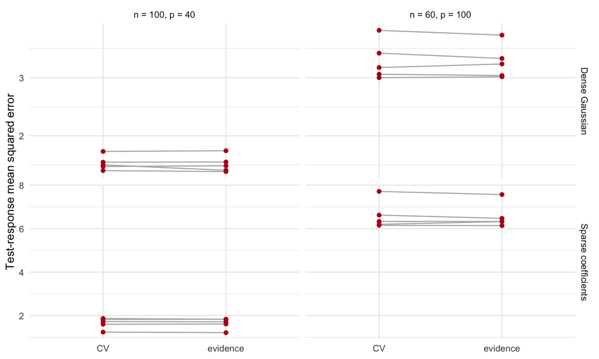

Figure 7: Independent-test prediction error for empirical Bayes marginal likelihood and five-fold cross-validation. Each point corresponds to one simulated training sample; lines pair the selectors on the same sample. Panels distinguish design dimensions and coefficient-generating scenarios.

```r
evidence_sim_plot <- evidence_results$simulations
evidence_sim_plot$design <- paste0("n = ", evidence_sim_plot$n, ", p = ", evidence_sim_plot$p)
ggplot2::ggplot(evidence_sim_plot,
 ggplot2::aes(method, test_mse, group = repetition)) +
 ggplot2::geom_line(colour = "grey70") + ggplot2::geom_point(colour = "#b5121b") +
 ggplot2::facet_grid(signal ~ design, scales = "free_y") +
 ggplot2::labs(x = NULL, y = "Test-response mean squared error") +
 ggplot2::theme_minimal(base_size = 11)
```

Boundary outcomes are part of the analysis rather than discarded runs. The following table reports the returned search status for every selector and setting. A CV grid-boundary choice or a finite-search-boundary empirical Bayes choice should prompt a check of the candidate range in a substantive analysis.

```r
evidence_status <- aggregate(list(count = rep(1L, nrow(evidence_results$simulations))),
 evidence_results$simulations[, c("n", "p", "signal", "method", "boundary")], sum)
knitr::kable(evidence_status, row.names = FALSE,
 caption = "Observed selection statuses, including finite search boundaries and the null-model limit.")
```

Observed selection statuses, including finite search boundaries and the null-model limit.

| n | p | signal | method | boundary | count |
| --- | --- | --- | --- | --- | --- |
| 100 | 40 | Dense Gaussian | CV | interior | 5 |
| 60 | 100 | Dense Gaussian | CV | interior | 5 |
| 100 | 40 | Sparse coefficients | CV | interior | 5 |
| 60 | 100 | Sparse coefficients | CV | interior | 5 |
| 100 | 40 | Dense Gaussian | evidence | interior | 5 |
| 60 | 100 | Dense Gaussian | evidence | interior | 5 |
| 100 | 40 | Sparse coefficients | evidence | interior | 5 |
| 60 | 100 | Sparse coefficients | evidence | interior | 5 |

## 4.7 What changes when data or predictors are updated?

# 5 Ridge regression as the design grows

A sequence of ridge fits provides a useful setting in which to assess the value of updating a triangular factor. New observations change the information available about a fixed coefficient vector, whereas new predictors enlarge the model itself. Both operations can be represented as changes to an augmented least-squares design. This representation also allows us to consider more predictors than observations: a positive ridge penalty makes the augmented design full column rank even when the observed design is wide.

The comparison in this chapter concerns the numerical work required to fit the same specified model after a change in its design. We examine coefficient and prediction accuracy separately from elapsed time, and compare updating with a fresh LAPACK factorization of the augmented design. The penalty is specified in advance. Choosing it from the data is a separate procedure, discussed in the preceding chapter.

## 5.1 The augmented problem and the meaning of a fixed penalty

For a response matrix $Y\in\mathbb R^{n\times q}$ and design $X\in\mathbb R^{n\times p}$, consider
$$\widehat B_\alpha=\arg\min_B\{\|Y-XB\|_F^2+\alpha\|B\|_F^2\},\qquad
\alpha>0.$$
Writing
$$A_\alpha=\begin{bmatrix}X\\\sqrt\alpha I_p\end{bmatrix},\qquad
Y_\alpha=\begin{bmatrix}Y\\0_{p\times q}\end{bmatrix}$$
turns this criterion into an ordinary least-squares problem with a full-column-rank design. Indeed, for any nonzero vector $v$,
$$v^\top A_\alpha^\top A_\alpha v=\|Xv\|_2^2+\alpha\|v\|_2^2>0.$$
This argument does not require $p\le n$. If $A_\alpha=QR$, then
$$R^\top R=X^\top X+\alpha I_p,\qquad
R^\top Z=X^\top Y,\qquad R\widehat B_\alpha=Z.$$
The last two equations describe an R-only workflow, which maintains the response cross-product as well as the factor. They are not interchangeable, in numerical accuracy, with explicitly applying the orthogonal transformations to $Y_\alpha$. We therefore use the latter approach as an independent reference when checking the updated coefficients. The use of QR and augmented systems for least squares is discussed in Golub and Van Loan (2013) and Björck (2015).

The public ridge functions use the normalized criterion $\|Y-XB\|_F^2/n+\lambda\|B\|_F^2$, so the parameter in the augmented design is $\alpha=n\lambda$. Holding $\alpha$ fixed while adding observations consequently changes the equivalent normalized parameter to $\lambda_{n+m}=\alpha/(n+m)$. Holding $\lambda$ fixed instead changes the total penalty. We treat these two experiments separately rather than silently changing the optimization problem.

## 5.2 A reproducible fit with more predictors than observations

The following example has forty observations and eighty predictors. A positive penalty gives a unique fit, despite the rank deficiency of the unpenalized problem. The two public interfaces are compared with a QR solve of the augmented design, whose right-hand side is transformed orthogonally.

```r
set.seed(312)
n_wide <- 40L
p_wide <- 80L
X_wide <- matrix(rnorm(n_wide * p_wide), n_wide, p_wide)
y_wide <- rnorm(n_wide)
alpha_wide <- 8
lambda_wide <- alpha_wide / n_wide
wide_QR <- fastQR::qrridge(y_wide, X_wide, lambda_wide, type = "QR")
wide_R <- fastQR::qrridge(y_wide, X_wide, lambda_wide, type = "R")
A_wide <- rbind(X_wide, sqrt(alpha_wide) * diag(p_wide))
f_wide <- fastQR::qr_lapack(A_wide, output = "thin")
beta_reference <- backsolve(
  f_wide$R, crossprod(f_wide$Q, c(y_wide, rep(0, p_wide))))
c(QR_error = max(abs(wide_QR$coeff - beta_reference)),
  R_error = max(abs(wide_R$coeff - beta_reference)))
```

```
##     QR_error      R_error
## 1.137979e-15 5.273559e-16
```

```r
stopifnot(max(abs(wide_QR$coeff - beta_reference)) < 1e-10,
          max(abs(wide_R$coeff - beta_reference)) < 1e-10)
```

The legacy residual diagnostic $n-p$ is not a degrees-of-freedom formula for ridge regression. The updated interfaces return `NA` for this diagnostic and its associated variance estimates when $p>n$; the coefficients, fitted values and requested predictions remain available. Effective ridge degrees of freedom are obtained from the smoother matrix, as explained in the preceding chapter. A zero penalty still requires full column rank, and therefore cannot be used to obtain a unique wide-design fit through these interfaces.

## 5.3 Adding observations

Suppose that $U\in\mathbb R^{m\times p}$ contains new observations and $V\in\mathbb R^{m\times q}$ their responses. At fixed $\alpha$, the maintained quantities satisfy
$$R_{\rm new}^\top R_{\rm new}=R^\top R+U^\top U,
\qquad H_{\rm new}=H+U^\top V,\qquad H=X^\top Y.$$
The existing row-update routine applies to the augmented design. The penalty rows need not be added again: they are already represented in $R$.

```r
set.seed(313)
new_X <- matrix(rnorm(5L * p_wide), 5L, p_wide)
new_y <- rnorm(5L)
R_before <- fastQR::qr_lapack(A_wide, output = "R")
H_before <- crossprod(X_wide, y_wide)
R_after <- fastQR::rupdate(A_wide, R_before, U = t(new_X),
                          type = "row", fast = FALSE)
H_after <- H_before + crossprod(new_X, new_y)
beta_after <- backsolve(R_after, forwardsolve(t(R_after), H_after))
fit_after <- fastQR::qrridge(c(y_wide, new_y), rbind(X_wide, new_X),
                            lambda = alpha_wide / (n_wide + 5L), type = "R")
stopifnot(max(abs(beta_after - fit_after$coeff)) < 1e-10)
```

If the normalized parameter $\lambda$ must remain fixed, the required identity is instead
$$R_{\rm new}^\top R_{\rm new}
=R^\top R+U^\top U+m\lambda I_p.$$
One valid construction appends both the observation rows and the additional penalty rows $\sqrt{m\lambda}I_p$. This construction is exact, but its extra work can erase an advantage for updating. The timing comparison below includes this cost; a fixed-$\alpha$ result must not be presented as evidence of a fixed-$\lambda$ speedup.

## 5.4 Adding predictors

Let $W\in\mathbb R^{n\times k}$ contain new predictors. With the same penalty on every coefficient, the enlarged augmented design can be arranged as
$$\begin{bmatrix}
X&W\\\sqrt\alpha I_p&0\\0&\sqrt\alpha I_k
\end{bmatrix}.$$
The first $p$ columns are the old augmented design with $k$ zero rows appended. Their triangular factor is still $R$. The new columns have observation part $W$, zeros on the old penalty rows, and their own diagonal penalty block. Updating these columns therefore includes the penalty on the new coefficients; appending $W$ alone would solve a different problem.

```r
set.seed(314)
k_new <- 3L
W_new <- matrix(rnorm(n_wide * k_new), n_wide, k_new)
A_padded <- rbind(A_wide, matrix(0, k_new, p_wide))
W_augmented <- rbind(W_new, matrix(0, p_wide, k_new),
                     sqrt(alpha_wide) * diag(k_new))
R_enlarged <- fastQR::rupdate(A_padded, R_before, U = W_augmented,
                             type = "column", fast = FALSE)
H_enlarged <- rbind(H_before, crossprod(W_new, y_wide))
beta_enlarged <- backsolve(R_enlarged,
                           forwardsolve(t(R_enlarged), H_enlarged))
fit_enlarged <- fastQR::qrridge(y_wide, cbind(X_wide, W_new),
                               lambda_wide, type = "R")
stopifnot(max(abs(beta_enlarged - fit_enlarged$coeff)) < 1e-10)
```

This column update includes a triangular solve whose accuracy depends on conditioning. The positive penalty separates the augmented columns from exact linear dependence, but does not provide a uniform accuracy guarantee for arbitrarily small penalties. The tests below use a moderate specified penalty and report the observed errors against an orthogonal reference.

## 5.5 Accuracy and time for the same updated fit

The experiments use tall and wide observed designs, two response variables, batches of ten observations or five predictors, and five calibrated timed repetitions after warm-up. Both timed workflows return coefficients through an R-only solve. The update starts from existing factors and a cached response cross-product; the alternative rebuilds the augmented factor and response cross-product. Construction of the augmented matrices needed by each workflow and the final triangular solves are included. Random-data generation, validation and initial factorization are excluded from these single-change measurements. The reference uses LAPACK without pivoting in both cases.

```r
knitr::kable(ridge_comparison, digits = 3, row.names = FALSE,
 caption = "Median milliseconds per fit after a single design change. Speedup is recomputation time divided by updating time; values above one favor updating.")
```

Median milliseconds per fit after a single design change. Speedup is recomputation time divided by updating time; values above one favor updating.

| n | p | operation | update_ms | recompute_ms | speedup |
| --- | --- | --- | --- | --- | --- |
| 120 | 60 | columns_fixed_alpha | 0.094 | 0.164 | 1.750 |
| 120 | 240 | columns_fixed_alpha | 0.766 | 1.687 | 2.204 |
| 300 | 450 | columns_fixed_alpha | 2.437 | 5.875 | 2.410 |
| 120 | 60 | rows_fixed_alpha | 0.109 | 0.215 | 1.964 |
| 120 | 240 | rows_fixed_alpha | 0.766 | 1.625 | 2.122 |
| 300 | 450 | rows_fixed_alpha | 2.687 | 6.000 | 2.233 |
| 120 | 60 | rows_fixed_lambda | 0.160 | 0.211 | 1.317 |
| 120 | 240 | rows_fixed_lambda | 4.000 | 1.687 | 0.422 |
| 300 | 450 | rows_fixed_lambda | 24.500 | 6.000 | 0.245 |

```r
ridge_validation_display <- ridge_validation
ridge_validation_display[, 4:7] <- lapply(ridge_validation_display[, 4:7],
  function(x) formatC(x, format = "e", digits = 2))
knitr::kable(ridge_validation_display, row.names = FALSE,
 caption = "Relative coefficient and prediction errors against QR of the augmented design with an orthogonally transformed response. Errors are scaled by the larger of one and the reference norm.")
```

Relative coefficient and prediction errors against QR of the augmented design with an orthogonally transformed response. Errors are scaled by the larger of one and the reference norm.

| n | p | operation | coefficient_error | prediction_error | recompute_error | public_fit_error |
| --- | --- | --- | --- | --- | --- | --- |
| 120 | 60 | rows_fixed_alpha | 8.51e-16 | 8.69e-16 | 7.49e-16 | 8.03e-16 |
| 120 | 60 | rows_fixed_lambda | 9.74e-16 | 1.02e-15 | 7.66e-16 | 1.06e-15 |
| 120 | 60 | columns_fixed_alpha | 9.42e-16 | 8.09e-16 | 9.01e-16 | 1.07e-15 |
| 120 | 240 | rows_fixed_alpha | 6.17e-15 | 1.65e-15 | 6.10e-15 | 5.00e-15 |
| 120 | 240 | rows_fixed_lambda | 5.60e-15 | 1.64e-15 | 5.12e-15 | 4.34e-15 |
| 120 | 240 | columns_fixed_alpha | 6.25e-15 | 1.40e-15 | 6.28e-15 | 4.93e-15 |
| 300 | 450 | rows_fixed_alpha | 6.58e-15 | 2.52e-15 | 6.98e-15 | 5.31e-15 |
| 300 | 450 | rows_fixed_lambda | 6.04e-15 | 2.44e-15 | 7.29e-15 | 5.42e-15 |
| 300 | 450 | columns_fixed_alpha | 6.93e-15 | 2.09e-15 | 6.89e-15 | 5.16e-15 |

The difference between the two row experiments is part of the computational question. An observation update at fixed total penalty modifies only the data contribution, whereas retaining a fixed normalized penalty also modifies the regularization block. Likewise, a predictor update must introduce the new penalty directions. The measured comparison, including these operations, determines whether maintaining the factor is advantageous on a particular problem. The complete repetitions and validation values are saved with the guide rather than replaced by a universal speed claim.

## 5.6 Following the design across the boundary $p=n$

A sequence of changes tests whether errors accumulate in ways that a single update can conceal. One experiment adds predictors to a design with one hundred observations, increasing its width from sixty to one hundred and sixty columns. A second adds observations to a design with one hundred predictors, increasing its sample size from sixty to one hundred and sixty. Both hold $\alpha=20$ fixed and cross the unpenalized boundary $p=n$, while their augmented designs remain full column rank throughout.

Figure 8 displays the cumulative numerical work along each sequence. The same initial factorization cost is included in both curves. These path measurements are single elapsed-time trajectories, whereas the preceding table uses repeated calibrated calls. Small elapsed-time differences along the paths should therefore be read cautiously.

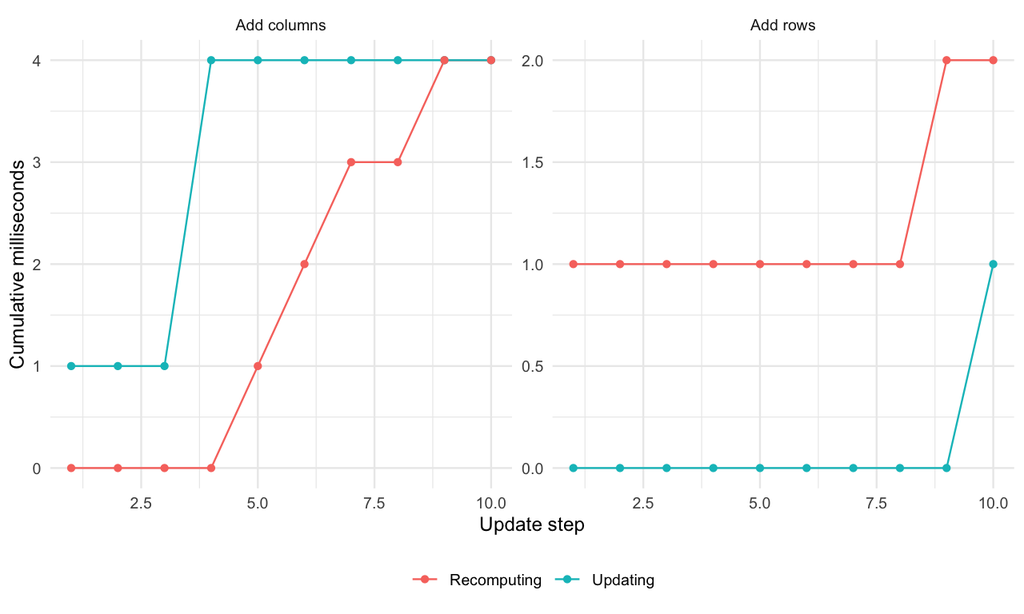

Figure 8: Cumulative elapsed time while adding observations or predictors at fixed total penalty. Both workflows include their initial factorization. Each panel shows one growing-design trajectory, rather than repeated timing estimates.

```r
ridge_time_plot <- rbind(
 transform(ridge_path, method = "Updating", milliseconds = 1000 * update_cumulative),
 transform(ridge_path, method = "Recomputing", milliseconds = 1000 * recompute_cumulative))
ggplot2::ggplot(ridge_time_plot,
 ggplot2::aes(step, milliseconds, colour = method)) +
 ggplot2::geom_line() + ggplot2::geom_point(size = 1.5) +
 ggplot2::facet_wrap(~operation, scales = "free_y") +
 ggplot2::labs(x = "Update step", y = "Cumulative milliseconds", colour = NULL) +
 ggplot2::theme_minimal(base_size = 11) +
 ggplot2::theme(legend.position = "bottom")
```

Figure 9 compares the updated coefficients and predictions with a fresh orthogonal reference at every step. Agreement across the transition through $p=n$ checks the augmented construction; it does not imply that an unpenalized wide-design problem has become identifiable.

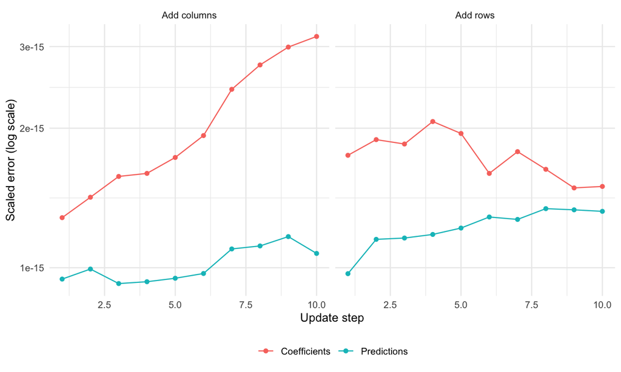

Figure 9: Coefficient and prediction errors along the growing-design sequences. Each reference is recomputed from the current augmented design by QR and orthogonal transformation of the response. Values below machine precision are clipped only for logarithmic display.

```r
ridge_error_plot <- rbind(
 transform(ridge_path, quantity = "Coefficients", error = coefficient_error),
 transform(ridge_path, quantity = "Predictions", error = prediction_error))
ggplot2::ggplot(ridge_error_plot,
 ggplot2::aes(step, pmax(error, .Machine$double.eps), colour = quantity)) +
 ggplot2::geom_line() + ggplot2::geom_point(size = 1.5) +
 ggplot2::scale_y_log10() + ggplot2::facet_wrap(~operation) +
 ggplot2::labs(x = "Update step", y = "Scaled error (log scale)", colour = NULL) +
 ggplot2::theme_minimal(base_size = 11) +
 ggplot2::theme(legend.position = "bottom")
```

The paths show how the factor and response information can be reused through a changing statistical model. They do not include selecting the penalty, and their times do not include evaluating predictions over a separate large test set. The distinction between maintaining numerical information and choosing a model is essential when using these examples to motivate a statistical application.

# 6 Numerical accuracy and reproducible timing

A numerical method has to produce an adequate answer before its execution time becomes informative. For matrix factorizations, this involves checking both the identities satisfied by the returned factors and the accuracy of the calculations that use them. These checks address different parts of a statistical computation: reconstructing a design accurately does not, by itself, establish that its regression coefficients can be estimated accurately when the design is nearly singular.

The timing experiments therefore follow the numerical comparisons. Each experiment specifies the information available at its starting point and the representation required at its end. Compact Householder information, explicit thin factors and complete factors involve different amounts of computation and storage. Keeping those requests separate makes the measurements relevant to an actual choice of workflow.

## 6.1 Accuracy as the condition number increases

The purpose of this experiment is to separate the quality of a factorization from the sensitivity of a coefficient estimate. Random Gaussian designs of a fixed shape are often reasonably well conditioned, so they do not provide a controlled way to study what happens near a rank deficiency. Instead, we construct each design from prescribed singular values,
$$X=U\operatorname{diag}(d_1,\ldots,d_p)V^\top,
\qquad U^\top U=I_p,\qquad V^\top V=I_p.$$
Here U has n rows and p orthonormal columns, while V is a square p-dimensional orthogonal matrix. The code obtains them by factorizing random matrices with base R and extracting their orthogonal factors.

The largest singular value is fixed at one, while the smallest is set to $1/\kappa_\star$. The intermediate values are spaced geometrically. The resulting spectral condition number is therefore $\kappa_2(X)=\kappa_\star$, up to floating-point rounding. Holding the orthogonal matrices $U$ and $V$ fixed across the sequence changes the separation of the singular values without introducing a new random orientation at every step.

A small singular value identifies a direction in coefficient space whose effect on the response is small. Recovering that component of a coefficient vector requires amplifying the corresponding response component, making the solution sensitive to small perturbations. To examine this numerical effect without additional observation noise, we choose a known coefficient vector $\beta$ and form $y=X\beta$. The reference coefficients are then available directly, rather than being supplied by another numerical solver.

We record two relative errors,
$$E_{\mathrm{rec}}
=\frac{\|X-\widehat Q\widehat R\|_F}{\|X\|_F},
\qquad
E_{\mathrm{coef}}
=\frac{\|\widehat\beta-\beta\|_2}{\|\beta\|_2}.$$
The first measures how closely the factors represent the input matrix. The second measures the error in the coefficients obtained after applying those factors to the response and solving the triangular system. An accurate representation of $X$ can coexist with a larger coefficient error because the inverse problem becomes more sensitive as $\kappa_2(X)$ grows. The experiment includes a normal-equation solve to show the additional effect of explicitly forming $X^\top X$ (Golub and Van Loan 2013; Björck 2015).

### 6.1.1 Computing the two coefficient estimates

For each design, `fastQR::qr(X, complete = FALSE)` returns $Q_1\in\mathbb R^{n\times p}$ and $R_1\in\mathbb R^{p\times p}$. The direct QR estimate is obtained from
$$c=Q_1^\top y,\qquad R_1\widehat\beta_{\mathrm{QR}}=c.$$
The first operation expresses the response in the orthonormal basis. The second recovers its coefficients relative to the original design columns. The projection identity
$$\|y-Xb\|_2^2
=\|Q_1^\top y-R_1b\|_2^2+\|(I_n-Q_1Q_1^\top)y\|_2^2$$
shows why this solves the least-squares problem: the final term is independent of b, and the triangular solve makes the first term zero. In the code, `crossprod(f$Q, y)` computes c and `backsolve(f$R, c)` performs the backward substitution. The factor R has the same singular values as X, so this solve remains sensitive when the design is ill conditioned; using QR does not make that sensitivity disappear.

The normal-equation estimate is computed through a different numerical route,
$$A=X^\top X,\qquad h=X^\top y,\qquad
A\widehat\beta_{\mathrm{NE}}=h.$$
These equations define the same coefficient vector in exact arithmetic when X has full column rank. They are represented by `solve(crossprod(X), crossprod(X, y))` in the experiment. Forming A explicitly introduces rounding into a system whose condition number is the square of that of X. The comparison therefore separates the sensitivity of the original coefficient problem from the additional effects of the computational route used to solve it.

```r
set.seed(2032)
n <- 160L
p <- 12L
U <- qr.Q(base::qr(matrix(rnorm(n * p), n, p)))
V <- qr.Q(base::qr(matrix(rnorm(p * p), p, p)))
beta <- seq(-1, 1, length.out = p)
condition_numbers <- 10^(0:8)
accuracy <- do.call(rbind, lapply(condition_numbers, function(kappa_target) {
  singular_values <- exp(seq(0, -log(kappa_target), length.out = p))
  X <- sweep(U, 2, singular_values, "*") %*% t(V)
  y <- drop(X %*% beta)
  f <- fastQR::qr(X, complete = FALSE)
  projected_response <- crossprod(f$Q, y)  # p coordinates in the Q basis
  b_qr <- backsolve(f$R, projected_response) # solve R beta = Q' y
  b_normal <- tryCatch(solve(crossprod(X), crossprod(X, y)),
                        error = function(e) rep(NA_real_, p))
  data.frame(condition = kappa_target,
    reconstruction = norm(X - f$Q %*% f$R, "F") / norm(X, "F"),
    QR_coefficients = sqrt(sum((b_qr - beta)^2) / sum(beta^2)),
    normal_equations = sqrt(sum((b_normal - beta)^2) / sum(beta^2)))
}))
knitr::kable(accuracy, digits = 12)
```

| condition | reconstruction | QR_coefficients | normal_equations |
| --- | --- | --- | --- |
| 1e+00 | 0 | 0.000e+00 | 0.000000e+00 |
| 1e+01 | 0 | 0.000e+00 | 0.000000e+00 |
| 1e+02 | 0 | 0.000e+00 | 0.000000e+00 |
| 1e+03 | 0 | 0.000e+00 | 2.200000e-11 |
| 1e+04 | 0 | 0.000e+00 | 4.211000e-09 |
| 1e+05 | 0 | 0.000e+00 | 3.986400e-08 |
| 1e+06 | 0 | 6.000e-12 | 1.390555e-05 |
| 1e+07 | 0 | 2.800e-11 | 2.664383e-03 |
| 1e+08 | 0 | 1.338e-09 | NA |

```r
stopifnot(max(accuracy$reconstruction) < 1e-10)
```

Figure 10 places the reconstruction and coefficient errors on logarithmic axes so that their different dependence on conditioning can be examined together. A flat reconstruction curve alongside a rising coefficient-error curve is compatible with an accurate factorization of a sensitive problem.

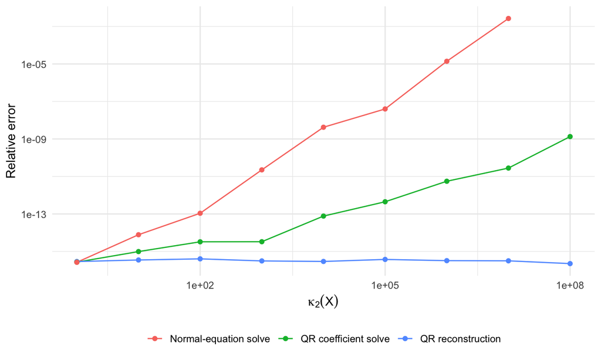

Figure 10: Relative reconstruction and coefficient errors versus the prescribed condition number. Missing normal-equation values indicate that the reference solver rejected the system as numerically singular.

```r
accuracy_long <- rbind(
  data.frame(condition = accuracy$condition, error = accuracy$reconstruction, metric = "QR reconstruction"),
  data.frame(condition = accuracy$condition, error = accuracy$QR_coefficients, metric = "QR coefficient solve"),
  data.frame(condition = accuracy$condition, error = accuracy$normal_equations, metric = "Normal-equation solve"))
ggplot2::ggplot(accuracy_long, ggplot2::aes(condition, pmax(error, .Machine$double.eps), colour = metric)) +
  ggplot2::geom_line(na.rm = TRUE) + ggplot2::geom_point(na.rm = TRUE) +
  ggplot2::scale_x_log10() + ggplot2::scale_y_log10() +
  ggplot2::labs(x = expression(kappa[2](X)), y = "Relative error", colour = NULL) +
  ggplot2::theme_minimal(base_size = 12) + ggplot2::theme(legend.position = "bottom")
```

For a full-column-rank design, $\kappa_2(X^\top X)=\kappa_2(X)^2$. Thus a design with condition number $10^8$ produces a cross-product matrix with condition number approximately $10^{16}$, close to the reciprocal of double-precision machine accuracy. Rounding in the formation of the cross-products can then have a substantial effect, and a solver may reasonably treat the resulting system as numerically singular. Missing points on the normal-equation curve indicate such a rejection; they do not represent zero error.

The QR coefficient curve comes from the explicit projection and triangular solve displayed in the code. Its comparison with the reconstruction curve concerns these particular calculations, rather than every possible use of a QR representation. Values smaller than machine epsilon are placed at epsilon in the plot to keep the logarithmic display readable; the underlying numerical values remain in the table.

## 6.2 Timing a row update against refactorization

The computational advantage of updating is relevant when a factorization is already available and only a small part of the design changes. The next experiment represents that situation by starting with a factor of an existing design and appending ten observations. Each method is asked to process the same enlarged matrix, but the methods differ in the information they produce.

The R-only update modifies the available triangular factor. A fresh `rchol()` call reconstructs a triangular factor from the enlarged design, providing a comparison with the same returned representation. A fresh thin QR calculation also constructs an explicit orthogonal factor. Its time is useful when that larger output is needed, while its difference from the R-only update includes both the cost of refactorization and the cost of returning Q. The initial factorization is excluded from the update timing because it is assumed to have been performed before the new observations arrive.

We use three design sizes, ten new rows, five repetitions, warm-up calls and adaptively sized batches to reduce clock-resolution effects. Random-data generation, correctness checks and plotting are excluded from timed regions. The reported times are **seconds per call**, not elapsed time for an entire batch.

```r
set.seed(2033)
repetitions <- 5L
sizes <- c(500L, 1000L, 2000L)
p <- 40L
m <- 10L
elapsed_per_call <- function(fun, batch_size) {
  unname(system.time(for (i in seq_len(batch_size)) fun())["elapsed"]) / batch_size
}
timing <- do.call(rbind, lapply(sizes, function(n) {
  X <- matrix(rnorm(n * p), n, p)
  U <- matrix(rnorm(p * m), p, m)
  X_new <- rbind(X, t(U))
  R <- fastQR::qr(X, complete = FALSE)$R
  methods <- list(
    "R update" = function() fastQR::rupdate(X, R, U, type = "row", fast = FALSE),
    "Fresh thin QR" = function() fastQR::qr(X_new, complete = FALSE),
    "Fresh R only" = function() fastQR::rchol(X_new))
  updated <- methods[[1]]()
  gram_error <- norm(crossprod(updated) - crossprod(X_new), "F") / norm(crossprod(X_new), "F")
  stopifnot(gram_error < 1e-10)
  invisible(lapply(methods, function(fun) fun()))
  batches <- vapply(methods, function(fun) {
    b <- 1L
    repeat {
      elapsed <- unname(system.time(for (i in seq_len(b)) fun())["elapsed"])
      if (elapsed >= .05 || b >= 4096L) break
      b <- b * 2L
    }
    b
  }, integer(1))
  do.call(rbind, lapply(seq_len(repetitions), function(rep) {
    # Randomize execution order within each repetition.
    order <- sample(names(methods))
    data.frame(n = n, p = p, added_rows = m, repetition = rep, method = order,
      batch_calls = unname(batches[order]),
      seconds = vapply(order, function(name)
        elapsed_per_call(methods[[name]], batches[[name]]), numeric(1)))
  }))
}))
timing_summary <- aggregate(seconds ~ n + method, timing, median)
knitr::kable(timing_summary, digits = 6,
             col.names = c("Original rows", "Method", "Median seconds per call"))
```

| Original rows | Method | Median seconds per call |
| --- | --- | --- |
| 500 | Fresh R only | 0.000293 |
| 1000 | Fresh R only | 0.000586 |
| 2000 | Fresh R only | 0.001187 |
| 500 | Fresh thin QR | 0.000797 |
| 1000 | Fresh thin QR | 0.001656 |
| 2000 | Fresh thin QR | 0.003250 |
| 500 | R update | 0.000022 |
| 1000 | R update | 0.000029 |
| 2000 | R update | 0.000043 |

Figure 11 compares the observed timings across the three row counts. The R-only update and R-only refactorization return the same kind of triangular factor. The fresh thin-QR calculation also constructs an explicit orthogonal factor, so its additional cost must be interpreted together with that larger output request.

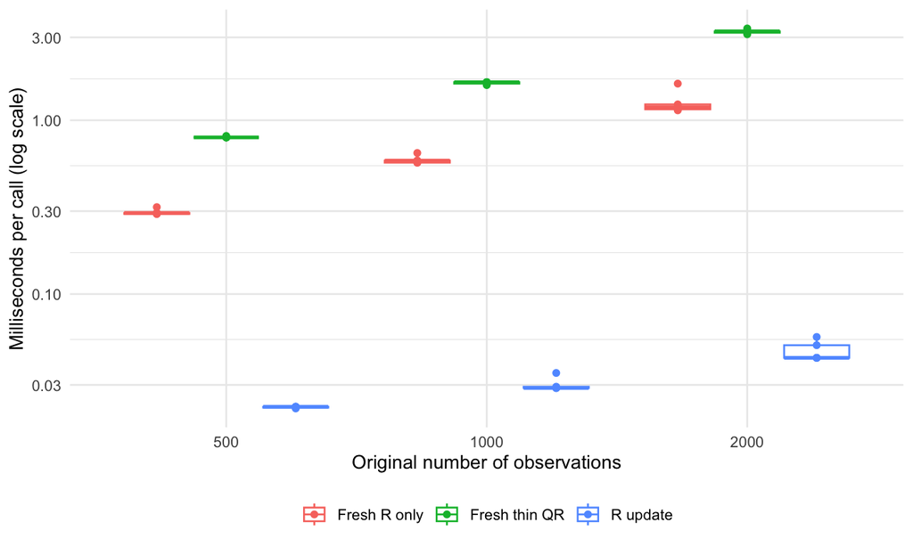

Figure 11: Measured time to obtain factors after adding ten observations. Initial factors are assumed available for the update. Points and boxes summarize five repetitions; each repetition averages a calibrated batch of calls. Each design has 40 columns and receives 10 new rows.

```r
ggplot2::ggplot(timing, ggplot2::aes(factor(n), seconds * 1000, colour = method)) +
  ggplot2::geom_boxplot(position = ggplot2::position_dodge(width = .8), outlier.shape = NA) +
  ggplot2::geom_point(position = ggplot2::position_dodge(width = .8), size = 1.6) +
  ggplot2::scale_y_log10() +
  ggplot2::labs(x = "Original number of observations", y = "Milliseconds per call (log scale)", colour = NULL) +
  ggplot2::theme_minimal(base_size = 12) + ggplot2::theme(legend.position = "bottom")
```

At the largest row count in this run, updating the available factor takes a median of **0.043 milliseconds**, compared with **1.19 milliseconds** for R-only refactorization. This comparison applies to ten added rows and excludes the initial factorization from the update cost. The fresh thin-QR method also constructs $Q$, so it answers a more demanding output request.

Timings depend on the machine, BLAS implementation, thread configuration and workload. A value printed as zero is below timer resolution and should not be interpreted as zero computational cost; increase the calibration duration if this occurs. These results illustrate this workload and do not establish a universal speed ranking. The code deliberately keeps input checking enabled.

## 6.3 Comparing QR interfaces

A compact factorization and an explicit basis can be used to solve the same mathematical problem while returning different amounts of information. A compact QR call stores R together with vectors and coefficients that describe Q. It can later apply those transformations to a response without forming Q. An explicit thin factorization has already performed that additional construction, while a pivoted factorization has also selected and recorded a column ordering.

Consequently, the interface-level table below identifies the exact call being timed. It describes the cost paid at that point in a workflow, rather than treating every object named QR as an identical output. The matched LAPACK experiment later in this chapter separately asks for the same thin or triangular representation from each implementation.

This comparison retains the five interfaces of the original benchmark: `base::qr`, `fastQR::qr`, `fastQR::qr_fast` with and without pivoting, and `Matrix::qr`. These calls return different representations: the timings compare the named interfaces, not identical output objects. The `Matrix` call below receives an ordinary dense R matrix, as in the original example; it is not a sparse-QR benchmark. Pivoting also performs additional work.

The default settings keep rebuilding this guide practical. Set `options(fastQR.guide.full_benchmarks = TRUE)` before `source("build.R")` to use the original large dimension grid and twenty repetitions in the scaling experiments. All displayed tables are generated from the actual settings, without loading historical timing files.

```r
full_benchmarks <- isTRUE(getOption("fastQR.guide.full_benchmarks", FALSE))
benchmark_reps <- if (full_benchmarks) 20L else 5L
benchmark_n <- if (full_benchmarks) 2000L else 500L
benchmark_p <- if (full_benchmarks) c(20L,40L,100L,200L,400L,800L,1200L,1500L,1800L) else c(20L,40L,80L)
measure_methods <- function(methods, repetitions) {
  invisible(lapply(methods, function(f) f()))
  batches <- vapply(methods, function(f) {
    b <- 1L
    repeat {
      seconds <- unname(system.time(for (i in seq_len(b)) f())["elapsed"])
      if (seconds >= .05 || b >= 4096L) break
      b <- b * 2L
    }
    b
  }, integer(1))
  do.call(rbind, lapply(seq_len(repetitions), function(rep) {
    order <- sample(names(methods))
    data.frame(repetition = rep, method = order, batch_calls = unname(batches[order]),
      seconds = vapply(order, function(k) elapsed_per_call(methods[[k]], batches[[k]]), numeric(1)))
  }))
}
set.seed(2041)
interface_n <- if (full_benchmarks) 1000L else 300L
interface_p <- if (full_benchmarks) 500L else 60L
interface_reps <- if (full_benchmarks) 10L else 5L
X_interface <- matrix(rnorm(interface_n * interface_p, 1), interface_n, interface_p)
interface_methods <- list(
  "base::qr (compact)" = function() base::qr(X_interface),
  "fastQR::qr (thin)" = function() fastQR::qr(X_interface, nb = 5, complete = FALSE),
  "qr_fast, no pivot" = function() fastQR::qr_fast(X_interface, pivot = FALSE),
  "qr_fast, pivot" = function() fastQR::qr_fast(X_interface, pivot = TRUE),
  "Matrix::qr (dense input)" = function() Matrix::qr(X_interface))
interface_timing <- measure_methods(interface_methods, interface_reps)
knitr::kable(aggregate(seconds ~ method, interface_timing, median), digits = 6,
  caption = sprintf("Median seconds per call: n = %d, p = %d, repetitions = %d.",
                    interface_n, interface_p, interface_reps))
```

Median seconds per call: n = 300, p = 60, repetitions = 5.

| method | seconds |
| --- | --- |
| Matrix::qr (dense input) | 0.000195 |
| base::qr (compact) | 0.000199 |
| fastQR::qr (thin) | 0.000379 |
| qr_fast, no pivot | 0.000189 |
| qr_fast, pivot | 0.000166 |

In this run, the smallest median time in the interface table belongs to **qr_fast, pivot**. This is a comparison of calls with different outputs: forming explicit thin factors includes work that a compact representation defers. Pivoting can change the algorithm and its cost; a small observed timing difference is not evidence that pivoting is intrinsically free or beneficial.

## 6.4 QR, Cholesky and linear-system scaling benchmarks

These experiments vary the number of predictors while keeping the observation count fixed. The QR workload compares factorization interfaces. The triangular-factor workload distinguishes starting from X from starting with $X^\top X$ already available. The solution workload starts even further downstream, with a common system $A\beta=h$ supplied to each solver.

That starting point matters for interpretation. If $A=X^\top X$ and $h=X^\top y$, factorizing A by QR still solves the normal equations: it does not undo the earlier formation of the cross-products. A direct QR least-squares calculation instead factorizes X and applies its transformations to y. Both routes can agree closely on a well-conditioned example, while their behavior can differ as conditioning deteriorates.

We retain both block-size choices, $5$ and $p/2$, and the three workloads from the original vignette. Within each dimension, every method receives the same data. Input generation, validation and plotting are excluded from the timings; execution order is randomized within each repetition, and calls are batched to reduce clock-resolution effects. Repetitions measure timing variability on a fixed matrix, rather than variation across independently generated problems.

- **QR decomposition:** `fastQR::qr` returns explicit thin factors, whereas `base::qr` returns compact factors. The different outputs must be considered when interpreting execution times.
- **Triangular factor:** `qrchol(X)` is compared with both `chol(crossprod(X))`, which includes forming the Gram matrix, and `chol(G)` with $G=X^\top X$ already available. Keeping both baselines makes the cost of forming $G$ explicit.
- **Linear-system solution:** both solvers receive the same precomputed $G=X^\top X$ and $h=X^\top y$. Thus neither method is charged for forming these inputs. This reproduces the original normal-equation workload; it is not a comparison of direct least-squares solvers acting on $X$.

```r
set.seed(2042)
benchmark_validation <- list()
scaling_timing <- do.call(rbind, lapply(benchmark_p, function(p) {
  n <- benchmark_n
  X <- matrix(rnorm(n * p), n, p)
  y <- rnorm(n)
  G <- crossprod(X); h <- crossprod(X, y)
  block <- max(1L, p %/% 2L)
  b_reference <- base::qr.solve(G, h)
  errors <- numeric()
  for (nb in c(5L, block)) {
    f <- fastQR::qr(X, nb = nb, complete = FALSE)
    U <- fastQR::qrchol(X, nb = nb)
    b <- fastQR::qrsolve(A = G, b = h, nb = nb)
    errors <- c(errors, norm(X - f$Q %*% f$R, "F") / norm(X, "F"),
      norm(crossprod(U) - G, "F") / norm(G, "F"),
      sqrt(sum((b - b_reference)^2)) / max(1, sqrt(sum(b_reference^2))))
  }
  stopifnot(max(errors) < 1e-8)
  benchmark_validation[[as.character(p)]] <<- data.frame(p = p, max_relative_error = max(errors))
  workloads <- list(
    QR = list("fastQR, nb = 5" = function() fastQR::qr(X, nb = 5, complete = FALSE),
      "fastQR, nb = p/2" = function() fastQR::qr(X, nb = block, complete = FALSE),
      "base QR (compact)" = function() base::qr(X)),
    Cholesky = list("qrchol, nb = 5" = function() fastQR::qrchol(X, nb = 5),
      "qrchol, nb = p/2" = function() fastQR::qrchol(X, nb = block),
      "chol, Gram available" = function() base::chol(G),
      "crossprod + chol" = function() base::chol(crossprod(X))),
    Solve = list("qrsolve, nb = 5" = function() fastQR::qrsolve(G, h, nb = 5),
      "qrsolve, nb = p/2" = function() fastQR::qrsolve(G, h, nb = block),
      "base qr.solve" = function() base::qr.solve(G, h)))
  do.call(rbind, lapply(names(workloads), function(workload) {
    out <- measure_methods(workloads[[workload]], benchmark_reps)
    out$workload <- workload; out$n <- n; out$p <- p
    out
  }))
}))
benchmark_validation <- do.call(rbind, benchmark_validation)
knitr::kable(benchmark_validation, digits = 12,
             caption = "Largest relative validation error across the two block sizes and three workloads.")
```

Largest relative validation error across the two block sizes and three workloads.

|  | p | max_relative_error |
| --- | --- | --- |
| 20 | 20 | 0 |
| 40 | 40 | 0 |
| 80 | 80 | 0 |

```r
knitr::kable(aggregate(seconds ~ workload + n + p + method, scaling_timing, median), digits = 6,
             caption = "Median seconds per call; dimensions and method names are reported explicitly.")
```

Median seconds per call; dimensions and method names are reported explicitly.

| workload | n | p | method | seconds |
| --- | --- | --- | --- | --- |
| QR | 500 | 20 | base QR (compact) | 0.000062 |
| QR | 500 | 40 | base QR (compact) | 0.000172 |
| QR | 500 | 80 | base QR (compact) | 0.000563 |
| Solve | 500 | 20 | base qr.solve | 0.000023 |
| Solve | 500 | 40 | base qr.solve | 0.000038 |
| Solve | 500 | 80 | base qr.solve | 0.000111 |
| Cholesky | 500 | 20 | chol, Gram available | 0.000004 |
| Cholesky | 500 | 40 | chol, Gram available | 0.000007 |
| Cholesky | 500 | 80 | chol, Gram available | 0.000061 |
| Cholesky | 500 | 20 | crossprod + chol | 0.000016 |
| Cholesky | 500 | 40 | crossprod + chol | 0.000023 |
| Cholesky | 500 | 80 | crossprod + chol | 0.000086 |
| QR | 500 | 20 | fastQR, nb = 5 | 0.000162 |
| QR | 500 | 40 | fastQR, nb = 5 | 0.000375 |
| QR | 500 | 80 | fastQR, nb = 5 | 0.000891 |
| QR | 500 | 20 | fastQR, nb = p/2 | 0.000133 |
| QR | 500 | 40 | fastQR, nb = p/2 | 0.000262 |
| QR | 500 | 80 | fastQR, nb = p/2 | 0.000547 |
| Cholesky | 500 | 20 | qrchol, nb = 5 | 0.000166 |
| Cholesky | 500 | 40 | qrchol, nb = 5 | 0.000391 |
| Cholesky | 500 | 80 | qrchol, nb = 5 | 0.000891 |
| Cholesky | 500 | 20 | qrchol, nb = p/2 | 0.000133 |
| Cholesky | 500 | 40 | qrchol, nb = p/2 | 0.000273 |
| Cholesky | 500 | 80 | qrchol, nb = p/2 | 0.000578 |
| Solve | 500 | 20 | qrsolve, nb = 5 | 0.000027 |
| Solve | 500 | 40 | qrsolve, nb = 5 | 0.000087 |
| Solve | 500 | 80 | qrsolve, nb = 5 | 0.000262 |
| Solve | 500 | 20 | qrsolve, nb = p/2 | 0.000019 |
| Solve | 500 | 40 | qrsolve, nb = p/2 | 0.000049 |
| Solve | 500 | 80 | qrsolve, nb = p/2 | 0.000137 |

```r
benchmark_plot <- function(workload_name) {
  dat <- subset(scaling_timing, workload == workload_name)
  ggplot2::ggplot(dat, ggplot2::aes(factor(p), seconds * 1000, colour = method)) +
    ggplot2::geom_boxplot(outlier.shape = NA, position = ggplot2::position_dodge(.8)) +
    ggplot2::geom_point(size = 1.3, position = ggplot2::position_dodge(.8)) +
    ggplot2::scale_y_log10() +
    ggplot2::labs(x = "Number of columns", y = "Milliseconds per call (log scale)", colour = NULL) +
    ggplot2::theme_minimal(base_size = 11) +
    ggplot2::theme(legend.position = "bottom") +
    ggplot2::guides(colour = ggplot2::guide_legend(nrow = 2, byrow = TRUE))
}
```

Figure 12 shows how the QR interface timings change as the number of columns grows. The two recursive block choices reveal the effect of partitioning the calculation, while the compact base-R output provides a separate interface-level comparison. Differences between these curves therefore reflect both computational methods and the representation returned.

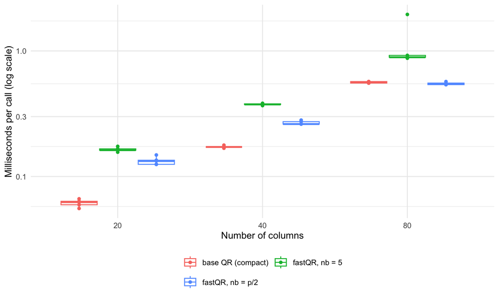

Figure 12: QR interface timings across column dimensions. Compact and explicit outputs are distinguished in the legend. Designs have 500 rows; each setting uses 5 timed repetitions.

```r
benchmark_plot("QR")
```

At the largest tested dimension (p = 80), the smallest median time is 0.547 milliseconds per call for fastQR, nb = p/2. Changing the block size changes the balance between panel factorization and matrix operations, so the preferred choice can depend on matrix dimensions and the linear-algebra library. The compact base-R result and explicit fastQR factors remain different deliverables.

The triangular-factor workload in Figure 13 separates the cost of factorizing an available cross-product matrix from the cost of first forming it. This distinction matters when deciding whether a timing is relevant to a calculation that starts from the observations themselves.

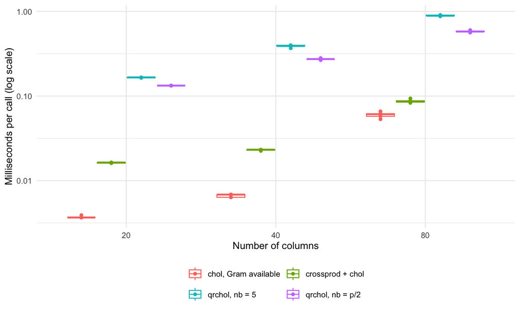

Figure 13: Triangular-factor timings, with separate baselines for an available Gram matrix and for its formation from X. Designs have 500 rows; each setting uses 5 timed repetitions.

```r
benchmark_plot("Cholesky")
```

At the largest tested dimension (p = 80), the smallest median time is 0.061 milliseconds per call for chol, Gram available. The two Cholesky baselines separate factorization from the cost of forming the Gram matrix. Compare `qrchol` with `crossprod + chol` when starting from the design alone; `chol, Gram available` is relevant when that matrix has already been computed. Their numerical-stability implications also differ because explicitly forming the Gram matrix squares the condition number.

Figure 14 isolates the solution stage for a shared, precomputed system. Data preparation and formation of the cross-products have already taken place. The comparison therefore measures the work of the displayed solver calls, with solution accuracy checked independently in the preceding validation table.

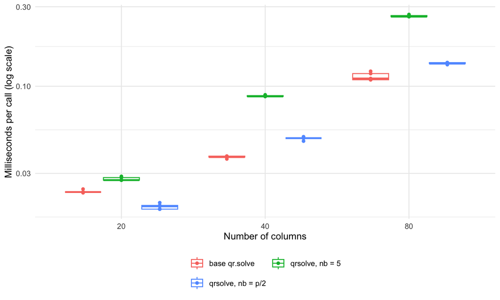

Figure 14: Solution times for the same precomputed normal-equation system. Designs have 500 rows; each setting uses 5 timed repetitions.

```r
benchmark_plot("Solve")
```

At the largest tested dimension (p = 80), the smallest median time is 0.111 milliseconds per call for base qr.solve. Both solvers start from the same precomputed normal-equation system. The differences therefore concern the solution stage, not preprocessing or prediction. The validation table checks agreement separately from execution time; a faster call would not be useful if it failed that check.

The normal-equation workload squares the condition number of the design, as discussed above. Good agreement on these random examples does not remove that limitation. The supplied large-grid option can be computationally expensive; the small default run supplies reproducible examples, not evidence of performance at untested dimensions. No historical cached measurements are mixed with these newly computed results.

## 6.5 Matched comparisons with unpivoted LAPACK

The following experiment separates the factorization algorithm from the representation requested by its caller. A small R interface calls the LAPACK routines linked to this R installation: `DGEQRF` computes compact Householder factors, and `DORGQR` forms an explicit orthogonal factor. No column pivoting is performed in these two routines. Comparing their thin output with fastQR’s thin output therefore avoids conflating pivoting or deferred construction of Q with the factorization itself.

The recorded run uses 4 shapes, with 300 or 600 rows and 20 or 60 columns, and 5 timed repetitions after warm-up. Each repetition uses a calibrated batch; the numbers below are median milliseconds per call. Compilation, random-data generation, numerical validation and plotting lie outside the timed regions. The R interfaces and their allocations are included. These measurements describe this machine and these shapes, rather than a universal ranking of implementations.

```r
initial_medians <- aggregate(seconds ~ n + p + workload + method, initial_lapack, median)
largest_thin <- subset(initial_medians, workload == "thin_unpivoted" & n == max(n) & p == max(p))
base_thin_seconds <- largest_thin$seconds[largest_thin$method == "LAPACK DGEQRF + DORGQR"]
largest_thin$milliseconds <- 1000 * largest_thin$seconds
largest_thin$LAPACK_over_method <- base_thin_seconds / largest_thin$seconds
knitr::kable(largest_thin[, c("n", "p", "method", "milliseconds", "LAPACK_over_method")],
             digits = 4, row.names = FALSE,
             caption = "Thin Q and R for the same largest design. A time ratio above one favors the named method over LAPACK.")
```

Thin Q and R for the same largest design. A time ratio above one favors the named method over LAPACK.

| n | p | method | milliseconds | LAPACK_over_method |
| --- | --- | --- | --- | --- |
| 600 | 60 | LAPACK DGEQRF + DORGQR | 0.7969 | 1.0000 |
| 600 | 60 | fastQR LAPACK thin | 0.9375 | 0.8500 |
| 600 | 60 | fastQR thin Givens | 9.2500 | 0.0861 |
| 600 | 60 | fastQR thin Householder | 2.1875 | 0.3643 |
| 600 | 60 | fastQR thin internal LAPACK | 0.7188 | 1.1087 |
| 600 | 60 | fastQR thin recursive | 0.6875 | 1.1591 |

```r
largest_R <- subset(initial_medians, workload == "R_unpivoted" & n == max(n) & p == max(p))
base_R_seconds <- largest_R$seconds[largest_R$method == "LAPACK DGEQRF + extract R"]
largest_R$milliseconds <- 1000 * largest_R$seconds
largest_R$LAPACK_over_method <- base_R_seconds / largest_R$seconds
knitr::kable(largest_R[, c("n", "p", "method", "milliseconds", "LAPACK_over_method")],
             digits = 4, row.names = FALSE,
             caption = "Triangular-factor-only requests on the same design, with no explicit Q returned.")
```

Triangular-factor-only requests on the same design, with no explicit Q returned.

| n | p | method | milliseconds | LAPACK_over_method |
| --- | --- | --- | --- | --- |
| 600 | 60 | LAPACK DGEQRF + extract R | 0.3984 | 1.0000 |
| 600 | 60 | fastQR LAPACK R | 0.5937 | 0.6711 |
| 600 | 60 | fastQR qrchol | 2.1875 | 0.1821 |
| 600 | 60 | fastQR rchol | 0.7969 | 0.5000 |

The distinction between `qr_thin()`, the direct Householder implementation and the recursive implementation matters: `qr_thin()` now uses an internal LAPACK backend, while the recursive implementation combines LAPACK panels with dense products. They perform different matrix operations even though all return a thin factorization. Likewise, an R-only interface should be compared with extracting R from a LAPACK factorization, rather than with a call that also forms Q. The complete raw results retain every shape and repetition.

Figure 15 compares calls that all return explicit thin factors for the same matrix. The logarithmic time axis keeps the faster and slower implementations visible within a single display. The repeated measurements describe timing variation on this fixed problem, rather than variation across independently generated datasets.

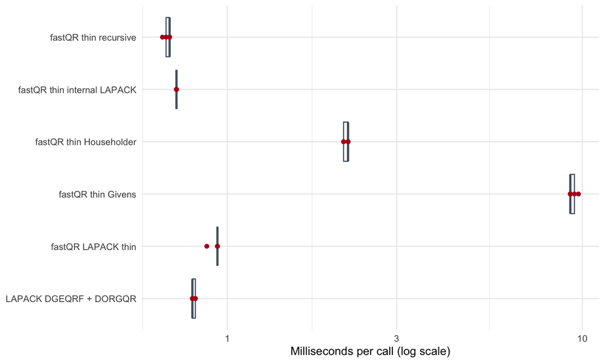

Figure 15: Thin-factor timings for a 600 by 60 design. Each point represents one calibrated repetition; elapsed time is shown on a logarithmic scale, with lower values indicating faster calls.

```r
plot_lapack <- subset(initial_lapack, workload == "thin_unpivoted" & n == max(n) & p == max(p))
ggplot2::ggplot(plot_lapack, ggplot2::aes(x = seconds * 1000, y = method)) +
  ggplot2::geom_boxplot(outlier.shape = NA, colour = "#526070") +
  ggplot2::geom_point(colour = "#b5121b", size = 1.5) +
  ggplot2::scale_x_log10() +
  ggplot2::labs(x = "Milliseconds per call (log scale)", y = NULL) +
  ggplot2::theme_minimal(base_size = 11)
```

The calls in Figure 15 return the same thin representation. For an update, the starting factors already exist, so the relevant alternative is recomputing the factors after the change. The next table keeps R-only and explicit thin-QR requests separate. The initial factors are excluded from these single-operation times; maintaining a full input Q still has a storage cost even when the requested result is thin.

```r
modification_medians <- aggregate(seconds ~ operation + workload + method, modifications_lapack, median)
matched_updates <- do.call(rbind, lapply(split(modification_medians,
  interaction(modification_medians$operation, modification_medians$workload, drop = TRUE)), function(z) {
    lapack <- grepl("LAPACK", z$method)
    data.frame(operation = gsub("_", " ", z$operation[1]), workload = z$workload[1],
      fastQR_ms = 1000 * z$seconds[!lapack], LAPACK_ms = 1000 * z$seconds[lapack],
      LAPACK_over_fastQR = z$seconds[lapack] / z$seconds[!lapack])
}))
knitr::kable(matched_updates, digits = 4, row.names = FALSE,
             caption = sprintf("Single modifications of an initial %d by %d design, with batches of %d rows or columns. Ratios above one favor updating with fastQR.", max(lapack_cfg$n), max(lapack_cfg$p), lapack_cfg$batch))
```

Single modifications of an initial 600 by 60 design, with batches of 3 rows or columns. Ratios above one favor updating with fastQR.

| operation | workload | fastQR_ms | LAPACK_ms | LAPACK_over_fastQR |
| --- | --- | --- | --- | --- |
| add columns | R only | 0.0820 | 0.4297 | 5.2381 |
| add rows | R only | 0.0498 | 0.4063 | 8.1569 |
| delete columns | R only | 0.0273 | 0.3672 | 13.4286 |
| delete rows | R only | 0.0229 | 0.4063 | 17.7021 |
| add columns | Thin QR | 2.6875 | 0.8750 | 0.3256 |
| add rows | Thin QR | 1.1563 | 0.8281 | 0.7162 |
| delete columns | Thin QR | 0.1719 | 0.7344 | 4.2727 |
| delete rows | Thin QR | 2.6250 | 0.7969 | 0.3036 |

An advantage for updating R does not imply the same advantage for updating explicit QR factors, nor does it establish an advantage for an initial factorization. The appropriate choice depends on whether the factors already exist and whether subsequent calculations need Q. The downloadable benchmark archive contains the R driver, the unpivoted LAPACK adapter and the raw timings, allowing these comparisons to be rerun on another machine.

## 6.6 Ridge updates: accuracy and speed on tall and wide designs

The ridge experiments provide a statistical application in which retaining a triangular factor has a measured computational advantage, including when the observed design has more columns than rows. The chapter *Ridge regression as the design grows* gives the augmented-design construction and the complete workflow. Here we collect its final numerical comparisons alongside the other timing results, so the statistical application can be assessed under the same reporting conventions.

Both workflows return the updated ridge coefficients through an R-only solve and account for the response cross-product. The starting factorization is available to the update but is excluded from both single-change timing measurements. Recomputing uses a fresh unpivoted LAPACK factorization of the augmented design. The table shows median milliseconds per call from five calibrated repetitions, including each workflow’s required matrix construction and triangular solves.

```r
final_ridge_results <- read.csv(file.path(lapack_root, "results/bench_ridge_summary.csv"))
knitr::kable(final_ridge_results, digits = 3, row.names = FALSE,
 caption = "Final ridge comparison for additions of ten observations or five predictors. Speedup is recomputation time divided by updating time; values above one favor updating.")
```

Final ridge comparison for additions of ten observations or five predictors. Speedup is recomputation time divided by updating time; values above one favor updating.

| n | p | operation | update_ms | recompute_ms | speedup |
| --- | --- | --- | --- | --- | --- |
| 120 | 60 | columns_fixed_alpha | 0.094 | 0.164 | 1.750 |
| 120 | 240 | columns_fixed_alpha | 0.766 | 1.687 | 2.204 |
| 300 | 450 | columns_fixed_alpha | 2.437 | 5.875 | 2.410 |
| 120 | 60 | rows_fixed_alpha | 0.109 | 0.215 | 1.964 |
| 120 | 240 | rows_fixed_alpha | 0.766 | 1.625 | 2.122 |
| 300 | 450 | rows_fixed_alpha | 2.687 | 6.000 | 2.233 |
| 120 | 60 | rows_fixed_lambda | 0.160 | 0.211 | 1.317 |
| 120 | 240 | rows_fixed_lambda | 4.000 | 1.687 | 0.422 |
| 300 | 450 | rows_fixed_lambda | 24.500 | 6.000 | 0.245 |

For the design with 300 observations and 450 predictors, updating after the addition of ten observations takes 2.69 ms, compared with 6.00 ms for recomputation, a speed advantage of 2.23 times. Adding five predictors takes 2.44 ms with updating and 5.87 ms with recomputation, a speed advantage of 2.41 times. Both comparisons hold the total penalty $\alpha$ fixed and produce the same target ridge fit. They demonstrate a measured benefit from reusing the existing factor and response information, including when $p>n$.

Figure 16 makes the size and direction of the time advantage explicit. At fixed total penalty, the measured observation and predictor updates are faster than rebuilding the augmented factor in these settings. Keeping the normalized penalty fixed is a different workload: adding observations changes the penalty block as well, and the construction used here is slower for the wide designs. The figure retains that case rather than transferring a fixed-total-penalty advantage to a different optimization problem.

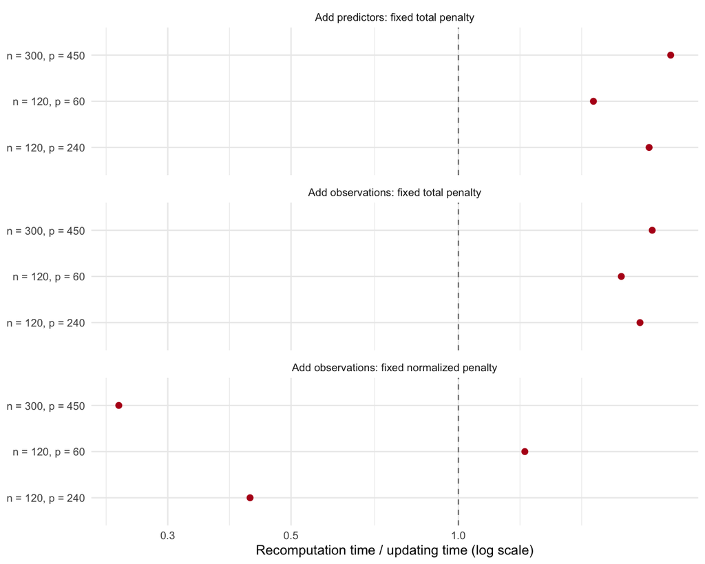

Figure 16: Ridge updating speed relative to refactorization on the same target fit. Values to the right of one favor updating. Panels distinguish predictor additions at fixed total penalty, observation additions at fixed total penalty, and observation additions at fixed normalized penalty; all cases are retained.

```r
final_ridge_results$design <- paste0("n = ", final_ridge_results$n, ", p = ", final_ridge_results$p)
final_ridge_results$operation_label <- factor(final_ridge_results$operation,
 levels = c("columns_fixed_alpha", "rows_fixed_alpha", "rows_fixed_lambda"),
 labels = c("Add predictors: fixed total penalty", "Add observations: fixed total penalty",
            "Add observations: fixed normalized penalty"))
ggplot2::ggplot(final_ridge_results, ggplot2::aes(speedup, design)) +
 ggplot2::geom_vline(xintercept = 1, linetype = 2, colour = "grey50") +
 ggplot2::geom_point(colour = "#b5121b", size = 2) +
 ggplot2::scale_x_log10() + ggplot2::facet_wrap(~operation_label, ncol = 1) +
 ggplot2::labs(x = "Recomputation time / updating time (log scale)", y = NULL) +
 ggplot2::theme_minimal(base_size = 11)
```

The time comparison is accompanied by independent numerical validation. Across these fits, the largest scaled coefficient or prediction discrepancy from the orthogonal augmented-QR reference is 7.29e-15. These checks support the reported examples; they do not establish stability for arbitrarily small penalties or a universal timing ranking. In particular, the comparison maintains a primal triangular factor of size $p$ by $p$. A dual formulation can be attractive when $p$ is much larger than $n$, and is a different computational alternative from the update-versus-recompute question measured here.

## 6.7 Record the computational environment

```r
packageVersion("fastQR")
```

```
## [1] '1.1.6'
```

```r
Sys.info()[c("sysname", "release", "machine")]
```

```
##  sysname  release  machine
## "Darwin" "23.3.0"  "arm64"
```

```r
Sys.getenv(c("OMP_NUM_THREADS", "OPENBLAS_NUM_THREADS", "VECLIB_MAXIMUM_THREADS"))
```

```
##        OMP_NUM_THREADS   OPENBLAS_NUM_THREADS VECLIB_MAXIMUM_THREADS
##                     ""                     ""                     ""
```

# 7 Mathematical background and further reading

The computational ideas in this guide build on standard orthogonal factorizations and their modification after changes to a matrix. For full treatments, see Golub and Van Loan (2013) and Björck (2015); for least-squares algorithms, see Björck (2024). The package authors develop updating methods and statistical applications in Bernardi, Busatto, and Cattelan (2024).

## 7.1 Why orthogonal transformations?

Consider the full-column-rank least-squares problem
$$\widehat\beta=\arg\min_{b\in\mathbb R^p}\|y-Xb\|_2^2,
\qquad X\in\mathbb R^{n\times p},\quad y\in\mathbb R^n,\quad n\ge p.$$
The thin factorization $X=Q_1R_1$ separates an orthonormal basis $Q_1$ for the column space from the coordinates stored in the triangular matrix $R_1$. Complete that basis to $Q=[Q_1,Q_2]$, so that $Q^\top Q=I_n$. Orthogonal multiplication preserves Euclidean length, and
$$Q^\top(y-Xb)
=\begin{pmatrix}Q_1^\top y-R_1b\\Q_2^\top y\end{pmatrix}.$$
Taking squared lengths gives
$$\|y-Xb\|_2^2
=\|Q_1^\top y-R_1b\|_2^2+\|Q_2^\top y\|_2^2.$$
The second term is unchanged when $b$ changes. Because $R_1$ is nonsingular, the first term can be made zero by solving
$$c=Q_1^\top y\in\mathbb R^p,
\qquad R_1\widehat\beta=c.$$
These are the two computational stages of a direct QR least-squares solve: project the response onto the orthonormal basis, then recover its coordinates relative to the original columns of $X$. In R, the projection is `crossprod(Q1, y)` and the triangular solution is `backsolve(R1, c)`. No inverse of $R_1$ is formed.

The triangular structure determines the order of the solve. The last equation gives $\widehat\beta_p=c_p/r_{pp}$; the preceding equations are recovered backwards through
$$\widehat\beta_j
=\frac{c_j-\sum_{k=j+1}^p r_{jk}\widehat\beta_k}{r_{jj}},
\qquad j=p-1,\ldots,1.$$
The nonzero diagonal entries required here follow from full column rank. The fitted response and residual are
$$\widehat y=Q_1Q_1^\top y,
\qquad e=y-\widehat y=(I_n-Q_1Q_1^\top)y.$$
Thus $Q_1^\top e=0$: the residual is orthogonal to every direction used to construct the fit. This identity supplies a useful numerical check in addition to agreement between coefficient vectors.

If only $R_1$ and $h=X^\top y$ are retained, the same coefficients follow from $R_1^\top R_1\widehat\beta=h$. The calculation then requires a forward solve followed by a backward solve,
$$R_1^\top z=h,\qquad R_1\widehat\beta=z.$$
In exact arithmetic, $z=Q_1^\top y$, since $X^\top y=R_1^\top Q_1^\top y$. This relation explains why an R-only representation can support regression, and why the right-hand side has to be maintained alongside the factor. The numerical consequences of forming cross-products are examined in the accuracy chapter (Golub and Van Loan 2013; Björck 2024).

## 7.2 Classical and modified Gram–Schmidt

Let $X=[x_1,\ldots,x_p]\in\mathbb R^{n\times p}$ have linearly independent columns, with $n\geq p$. Classical Gram–Schmidt constructs an orthonormal basis for their span. At step $k$, set
$$\begin{aligned}
r_{jk}&=q_j^\top x_k\quad(j<k),\\
v_k&=x_k-\sum_{j=1}^{k-1}r_{jk}q_j,\\
r_{kk}&=\|v_k\|_2,\qquad q_k=v_k/r_{kk}.
\end{aligned}$$
The empty sum at $k=1$ is zero. Full column rank ensures $r_{kk}>0$ in exact arithmetic. With $r_{jk}=0$ for $j>k$, these identities give $X=QR$ and $Q^\top Q=I_p$. The temporary residual $v_k$ is distinct from the normalized vector $q_k$.

Modified Gram–Schmidt instead starts with $v=x_k$ and, for $j=1,\ldots,k-1$, successively computes
$$r_{jk}=q_j^\top v,\qquad v\leftarrow v-r_{jk}q_j;$$
it then sets $r_{kk}=\|v\|_2$ and $q_k=v/r_{kk}$. The two algorithms are equivalent in exact arithmetic, but their floating-point behavior differs: computing projections from the updated residual generally reduces loss of orthogonality. Reorthogonalization may still be needed for difficult problems (Golub and Van Loan 2013; Björck 2015).

At each step, the inner products describe the part of the current column already explained by the existing basis. Subtracting those components leaves a residual direction; normalizing that residual supplies the next basis vector. The recorded coefficients give the identity $x_k=\sum_{j\le k}q_jr_{jk}$, so the construction produces both factors rather than Q alone.

The following educational implementation follows the modified scheme. Its diagonal check detects a residual that is too small relative to the input column to normalize reliably. That check is useful for understanding the algorithm, but it is not a general rank-revealing procedure. The example checks reconstruction and orthogonality separately on a well-conditioned design.

```r
mgs <- function(X) {
  n <- nrow(X); p <- ncol(X)
  Q <- matrix(0, n, p); R <- matrix(0, p, p)
  for (k in seq_len(p)) {
    v <- X[, k]
    if (k > 1L) for (j in seq_len(k - 1L)) {
      R[j, k] <- sum(Q[, j] * v)
      v <- v - R[j, k] * Q[, j]
    }
    R[k, k] <- sqrt(sum(v^2))
    if (R[k, k] <= .Machine$double.eps * sqrt(sum(X[, k]^2)))
      stop("Numerically dependent column: use a rank-revealing factorization.")
    Q[, k] <- v / R[k, k]
  }
  list(Q = Q, R = R)
}
set.seed(2040)
X_gs <- matrix(rnorm(80 * 8), 80, 8)
gs <- mgs(X_gs)
gs_checks <- c(reconstruction = norm(X_gs - gs$Q %*% gs$R, "F") / norm(X_gs, "F"),
               orthogonality = norm(crossprod(gs$Q) - diag(8), "F"))
gs_checks
```

```
## reconstruction  orthogonality
##   1.154784e-16   1.019128e-15
```

```r
stopifnot(max(gs_checks) < 1e-10)
```

## 7.3 Householder transformations and Givens rotations

Gram–Schmidt constructs basis vectors by successive projections. Householder QR instead transforms the matrix into triangular form using reflections. For a nonzero vector $v$, the matrix
$$H=I-2vv^\top/(v^\top v)$$
is symmetric and satisfies $H^\top H=I$. For a column segment $x$, a reflector can be chosen so that $Hx=\alpha e_1$, eliminating every entry of that segment except its first. Applying such a transformation to successive trailing submatrices removes the entries below the diagonal without changing Euclidean lengths.

If the embedded reflections satisfy $H_s\cdots H_1X=R$, then
$$X=QR,\qquad Q=H_1\cdots H_s,$$
with the full or thin factors selected as required. Each reflection is represented by a vector and a coefficient, so its action can be applied without storing a dense matrix H. Compact Householder output retains that information. Forming Q, multiplying by Q and multiplying by its transpose are related operations, but need not incur the same storage cost.

A Givens rotation acts on just two coordinates. With
$$G=\begin{pmatrix}c&s\\-s&c\end{pmatrix},\qquad c^2+s^2=1,$$
choosing $c=a/\sqrt{a^2+b^2}$ and $s=b/\sqrt{a^2+b^2}$ gives
$$G\begin{pmatrix}a\\b\end{pmatrix}
=\begin{pmatrix}\sqrt{a^2+b^2}\\0\end{pmatrix}$$
when $(a,b)\ne(0,0)$. Implementations compute the rotation parameters with appropriate numerical safeguards. Because a rotation changes only a pair of coordinates, a sequence of rotations can restore triangular form after a local insertion or deletion.

Both constructions use orthogonal transformations to control the propagation of rounding error. They do not remove sensitivity already present in a nearly singular design. The distinction between an accurate factorization and an accurate coefficient vector is therefore retained throughout the numerical experiments (Golub and Van Loan 2013; Björck 2015).

## 7.4 What a row update changes

Suppose $X=Q_1R_1$ has already been computed and a batch of $m$ observations is represented by $U^\top$, where $U\in\mathbb R^{p\times m}$. The enlarged design is
$$X_+=\begin{pmatrix}X\\U^\top\end{pmatrix}.$$
Applying the previously available orthogonal transformation to the original observation block reduces the new factorization problem to triangularizing
$$\begin{pmatrix}R_1\\U^\top\end{pmatrix}
\in\mathbb R^{(p+m)\times p},$$
together with zero rows that do not affect the triangular factor. The new observations have to be incorporated, but the original n-row design need not be factorized again to obtain R.

The corresponding cross-product identity is
$$X_+^\top X_+=R_1^\top R_1+UU^\top.$$
It also explains what additional information a regression update needs. If $y_+$ is the vector of responses for the new batch, the right-hand side becomes $h_+=h+Uy_+$, where $h=X^\top y$. Updating R alone does not update that response-dependent quantity.

Deleting observations reverses the signs in both updates. The resulting cross-product matrix is positive semidefinite when the deleted rows belong to the original design; it is positive definite precisely when the remaining design has full column rank. A downdated factor may still represent a rank-deficient design, but the unpivoted triangular coefficient solve then requires further treatment. Near a loss of rank, cancellation in the subtraction makes the numerical checks especially important.

## 7.5 Ridge as augmented least squares

For the normalized ridge criterion used in the regression chapter, define the augmented response and design by
$$\widetilde y=\begin{pmatrix}y\\0_p\end{pmatrix}\in\mathbb R^{n+p},\qquad
\widetilde X=\begin{pmatrix}X\\\sqrt{n\lambda}I_p\end{pmatrix}
\in\mathbb R^{(n+p)\times p}.$$
The $p$ additional entries of $\widetilde y$ are zero, and the $p$ additional rows of $\widetilde X$ encode the penalty. For $b\in\mathbb R^p$,

$$\begin{aligned}
\|\widetilde y-\widetilde Xb\|_2^2
&=\left\|\begin{pmatrix}y-Xb\\-\sqrt{n\lambda}b\end{pmatrix}\right\|_2^2\\
&=\|y-Xb\|_2^2+n\lambda\|b\|_2^2.
\end{aligned}$$
Multiplying the normalized criterion by n does not change its minimizer, so the ridge estimate is the ordinary least-squares solution for these augmented data. With a thin factorization $\widetilde X=\widetilde Q_1\widetilde R_1$, it can be computed by
$$\widetilde R_1\widehat\beta_\lambda
=\widetilde Q_1^\top\widetilde y.$$
Equivalently, differentiating the original criterion gives
$$(X^\top X+n\lambda I_p)\widehat\beta_\lambda=X^\top y.$$
The extra rows imply $\widetilde R_1^\top\widetilde R_1=X^\top X+n\lambda I_p$. An R-only calculation therefore uses this factor in two triangular solves, just as in the unpenalized case. A positive penalty makes the system positive definite even when X has dependent columns, although a particular fitting interface can impose additional restrictions on input dimensions.

The augmented formulation is an independent way to check the implementations. It also identifies the scale of the penalty: the factor n is a consequence of dividing the data loss by n. Within cross-validation, n is replaced by the size of the corresponding training set.

The intercept is handled separately in the ridge tutorial by centering. If a column of ones were simply included in the penalized design, that coefficient would also be penalized. Predictor means and scales must be estimated again within each cross-validation training fold.

## 7.6 Choosing a representation

The representation should retain the information needed by the next calculation. A compact factorization stores the transformations defining Q and is useful when only their action on vectors is required. Thin factors make the column-space basis explicit, supporting projections and direct QR solves. A full factorization also retains an orthogonal complement, which is used by some update routines but can require substantially more storage for a tall design.

An R-only representation is sufficient when subsequent operations need the cross-product information $R^\top R$ and triangular solves. Regression still requires a compatible right-hand side such as $X^\top y$, and insertion of new predictors can require cross-products with their observed values. These requirements distinguish the information needed by the algorithm from the matrix finally returned to R.

The examples use reconstruction identities, independent coefficient calculations and recorded timings to examine those choices. The function guide describes the interfaces, while the numerical experiments show how representation, conditioning and the starting information affect the computation.

# References

Bernardi, Mauro, Claudio Busatto, and Manuela Cattelan. 2024. “Fast QR Updating Methods for Statistical Applications.” https://arxiv.org/abs/2412.05905.

Björck, Åke. 2015. *Numerical Methods in Matrix Computations*. Vol. 59. Texts in Applied Mathematics. Springer, Cham. https://doi.org/10.1007/978-3-319-05089-8.

———. 2024. *Numerical Methods for Least Squares Problems: Second Edition*. Philadelphia, PA: Society for Industrial; Applied Mathematics. https://doi.org/10.1137/1.9781611977950.

Golub, Gene H., and Charles F. Van Loan. 2013. *Matrix Computations*. Fourth. Johns Hopkins Studies in the Mathematical Sciences. Johns Hopkins University Press, Baltimore, MD.

Karabatsos, George. 2015. “Fast Marginal Likelihood Estimation of the Ridge Parameter(s) in Ridge Regression and Generalized Ridge Regression for Big Data.” https://doi.org/10.48550/arXiv.1409.2437.

Rasmussen, Carl Edward, and Christopher K. I. Williams. 2006. *Gaussian Processes for Machine Learning*. The MIT Press. https://gaussianprocess.org/gpml/.